# Bibliographie_These_IRIV

Sébastien HARSCOAT

5 février 2018

# Introduction

Les pathologies respiratoires sont un motif fréquent consultation aux urgences et nécessitent, dans la majorité des cas, une hospitalisation dans un service pour la suite de la prise en charge. Une part importante de ces patients sont atteints de pathologies pulmonaires atteignant les voies de conduction respiratoire. La principale caractéristique de ces pathologies est de présenter un syndrome obstructif par augmentation des résistances des bronchioles distales. Les deux pathologies les plus connues de cette famille sont l’asthme et la Broncho-Pneumopathie Chronique Obstructive (BPCO) associée ou non à un emphysème. Ces deux pathologies sont responsables d’une morbi-mortalité importante avec pour conséquences de nombreuses hospitalisations pour décompensation aiguë. Actuellement, il n’existe que deux moyens non invasifs de surveiller de façon continue une pathologie pulmonaire. Il s’agit de la saturation pulsée en oxygène (SpO2) et de la capnographie par lunettes nasales. La capnographie est un monitoring en temps réel du CO2 expiré, disponible et facilement réalisable dans les services d’urgences. Des modifications de la courbe de capnographie sont décrites dans la littérature en association avec l’atteinte obstructive de certaines pathologies comme l’asthme en rapport avec l’augmentation des résistances respiratoires. Cette approche descriptive ne permet pas d’objectiver quantitativement les troubles respiratoires sous-jacents. Pour le moment, aucun système ne permet de quantifier les variations et les modifications de ces courbes de CO2 expiré. A ce jour, les seuls examens permettant d’apprécier les résistances des voies aériennes et par conséquent leurs modifications, sont les explorations fonctionnelles respiratoires (EFR) avec l’étude des volumes et des débits respiratoires, notamment lors de la spirométrie. Les EFR sont considérés comme étant les examens de référence dans la mesure précise et objective d’une obstruction bronchique surtout chez le sujet asthmatique et BPCO. La réalisation d’EFR comporte des contraintes matérielles et physiques qui rendent son utilisation difficile dans un contexte de pathologie aiguë chez un patient instable sur le plan respiratoire ou cardiologique et nécessitant souvent une oxygénothérapie. Par ailleurs, il s’agit souvent de patients âgés qui n’ont plus la capacité de se soumettre à ce type d’explorations, qui demandent de la coopération et la mobilisation de grands volumes pulmonaires. Dans ce contexte, l’utilisation de la capnographie permettrait une évaluation et une surveillance plus aisée de la fonctionnalité respiratoire. Peu d’études montrent l’existence d’une relation quantifiable entre les courbes de capnographie et les résultats des EFR. L’objectif de ce travail est d’objectiver l’apport de la transformée en ondelettes sur l’analyse de la déformation de la courbe de capnographie permettant la distinction des patients pathologiques présentant un syndrome obstructif. Dans ce but, nous établiront dans un premier temps l’état des connaissances sur la technique de capnographie et particulièrement sur l’analyse de la courbe ainsi que de ses tentatives de modélisation. Puis nous développeront l’analyse du signal de capnographie par la transformée en ondelettes tout d’abord par une phase de simulation permettant d’observer le comportement de cette transformation en fonction de la déformation de la courbe. Nous terminerons par une phase expérimentale à l’aide de données de capnographie et de spirométrie recueillies sur des patients.

# Première Partie - Physiologie & Physiopathologie du Poumon

## Rappel d’Anatomie et de Physiologie Respiratoire

## Physiopathologie Pulmonaire

### Asthme

[1] L’asthme affecte environ 8% de la population adulte et jusqu’à 20% des enfants en Amérique du Nord, en Europe et en Australie. La plupart de ces patients ont une maladie légère à modérée qui peut être contrôlée avec des corticostéroïdes inhalés et un agoniste $\beta$-adrénergique inhalé à courte action. Cependant, on estime qu’environ 5% à 10% des patients asthmatiques présentent une maladie grave resistante au traitement habituelles, notamment l’administration de corticostéroïdes systémiques. Ce groupe de patients représente un sous-groupe important de patients asthmatiques. Par exemple, ils ont la plus grande déficience de leur mode de vie, leur maladie a de profondes répercussions sur le système de santé et leur traitement utilise un montant proportionnel de dollars consacrés aux soins de santé. En outre, ce fardeau est partagé de manière disproportionnée par les minorités et les femmes. De plus, notre compréhension de la physiopathologie de cet aspect de l’asthme est mal comprise. Compte tenu de l’importance de l’asthme sévère sur le coût du système de santé et de l’absence de connaissances bien définies sur les mécanismes de la maladie, l’Institut national du cœur, des poumons et du sang a parrainé un atelier intitulé «Physiopathologie de l’asthme sévère». évaluer un certain nombre de domaines d’intérêt / objectifs: (1) définir les caractéristiques de l’asthme sévère, (2) identifier les facteurs mécanistes associés à l’asthme sévère, (3) discuter des approches potentielles d’étude et de traitement, et (4) présenter des recommandations pour les besoins et l’orientation futurs de la recherche. Ce qui suit est un résumé de la présentation et de la discussion de l’atelier.

L’asthme est une maladie multifactorielle résultant de la conjonction de facteurs congénitaux (terrain atopique, anomalies constitutionnelles du muscle lisse…) et d’éléments liés à l’environnement(allergènes, polluants, infections…). Malgré de nombreux travaux, la physiopathologie de l’asthme reste controversée : l’efficacité des médiateurs [beta-adrdnergiques sur le spasme bronchique a conduit à mettre en avant le dysfonctionnement du systéme nerveux autonome, mais d’ autres facteurs interviennent, comme la réponse immunitaire locale aux allergènes, agents viraux et irritants tels que les polluants extérieurs. Tous ces mécanismes concourent, des degrés divers, au développement de la réaction inflammatoire bronchique, commune 5 l’asthme intrinsèque ou extrinsbque (allergique) [1]. Les phénomènes d’obstruction bronchique, variables dans le temps, associent de façon intriquée bronchospasme, sur lequel agissent les [Beta-2-mimétiques, et inflammation bronchique intégrant oedème paridtal, hypersécrétion et, de fagon plus tardive, remodelage (remodeling) des voies aériennes. Cette inflammation est présente un stade précoce de la maladie, parfois de faqon latente.

Aspects anatomopathologiques L’inflammation bronchique au cours de la maladie asthmatique a été démontrée à la fois par les études post mortem et par l’analyse de biopsies bronchiques et du LBA. Chez les patients décédés d’asthme, on note une hypertrophie du muscle lisse, un épaississement de la membrane basale, des bouchons de mucus obstruant les bronchioles terminales avec hyperplasie des cellules glandulaires et la présence de cellules inflammatoires infiltrant la muqueuse bronchique. Cet infiltrat est composé de polynucléaires éosinophiles, neutrophiles, de lymphocytes et de cellules mononuclées [3]. L’épaississement de la membrane basale, présenté à un stade précoce de la maladie, correspond à un dépôt de collagène de types I, III et V dans la région sous-épithéliale. Cette fibrose sous-épithéliale traduit l’activation des myofibroblastes présents en nombre accru dans la sous-muqueuse et est le reflet du remodeling [14].

+++++++ [3] La bronchocontstriction dans l’asthme est du à une baisse de l’AMPcyclique intracellulaire par relargage de médiateur (Histamine, fracteur chimiotactique des ésoinophiles et neutrophile, prostaglandine, bradykinine, PAF, Triptase, TNF, dérivées de l’acide arachidonique, cytokines). Augmente la perméablité capillaire créant un oedème péribronchique. Augmentation de la CPT et de la CRF, une certaine perte de la rétraction élastique entrainant un déplacement de la courbe pression-volume en haut et à gauche (comme dans l’emphysème). Il est vraisemblable que le bronchospasme touche les voies aériennes de tout calibre et la relation entre la conductance des voies aéreinnes et la pression de rétraction élastique est fortement perturbée. Le rétrécissement des voies aériennes principales larges est moyennes peut-être observé en bronchoscopie. L’hypoxémie artérielle est fréquente dans l’asthme. Elle est provoquée par une inégalité du rapport ventilation-perfusion (V/Q) avec des régions hypoventilées occasionnant un effet shunt. Des inégalités marquées de distribution du débit sanguin sont également observées. L’espace mort physiologique et le shunt physiologique sont généralement tous les deux anormalement élevés.

[4]

### Bronchite Chronique Obstructive - BPCO

[5] ++++ La bronchopneumopathie chronique obstructive (BPCO) se caractérise par une limitation irréversible du débit d’air mesurée pendant l’expiration forcée (1,2), provoquée soit par une augmentation de la résistance des petites voies aériennes conductrices (3,4,5), soit par une augmentation de la compliance pulmonaire due à une destruction emphysémateuse du parenchyme pulmonaire, (6) ou les deux. Les unités de résistance des voies respiratoires sont en cm H2O / L /s et pour la compliance en L / cm H2O, et leur produit (temps) fournit la constante de temps pour la vidange des poumons (7). Ces constantes sont reflétées par les mesures du volume d’air expirable en une seconde (VEMS) et de son rapport à la capacité vitale forcée (VEMS / FVC), qui sont des outils de dépistage fiables, car ils sont affectés à la fois par l’obstruction des voies respiratoires et par l’emphysème. Les lésions pulmonaires retrouvé dans la BPCO sont secondaire à une réponse immunitaire inflammatoire en réaction à une exposition chronique à des gaz et particules toxiques inhalées. Ce processus inflammatoire contribu à l’obstruction des petites voies aériennes conductrices au niveau des bronchioles …. Les atteintes histologiques comprennent une rupture de la barrière épithéliale, l’altération de l’appareil mucociliaire entrainant une baisse de la clairance avec accumulation d’exsudats inflammatoires muqueux dans la lumières des petites voies respiratoires, l’infiltration par des cellules inflammatoires ainsi que le dépot de tissu conjonctif dans les paroies de petites voies respiratories. Ce remodelage et cette réparation épaississent les parois des voies respiratoires, réduisent le calibre de la lumière et limitent l’augmentation normale du calibre produite par le gonflement des poumons. La destruction des poumons emphysémateux est associée à une infiltration du même type de cellules inflammatoires que celles trouvées dans les voies respiratoires. Le schéma centrolobulaire de destruction emphysémateuse est le plus étroitement associé au tabagisme. Bien que ciblant initialement les bronchioles respiratoires, des lésions distinctes se combinent pour détruire de gros volumes de tissu pulmonaire. Le schéma panacinaire de l’emphysème se caractérise par une implication plus uniforme de l’acinus et est associé à un déficit en alpha-1 antitrypsine. Ces processus inflammatoires fond intervenir l’immunité inée et l’immunité acquise. Durant la maladie plusieurs stade sont visibles. Intialement cela commence par une inflamation des bronches correspondant à la bronchite chronique. L’inflammation associée à la bronchite chronique se situe dans l’épithélium des voies aériennes centrales (diamètre interne supérieur à 4 mm), où elle s’étend le long des canaux des glandes jusqu’aux glandes produisant du mucus. Ce processus inflammatoire est associé à une augmentation de production de mucus, d’une clairance mucociliaire défectueuse et une altération de la barrière épithéliale induit par le système immunitaire inné de l’hôte. La bronchite chronique est également associée avec un épaississement des parois bronchiques principalement liée à une augmentation des dépôts de tissu conjonctif. Par la suite l’évolution naturelle de l’hypersécrétionde mucus associée à l’exposition chronique de tabac se fait au détriment d’une hypersecrétion purulente aggravant les phénomènes inflammatoire aboutissant à un syndrome obstructif. Bien que les termes bronchite chronique et obstruction des voies respiratoires soient souvent utilisés de manière interchangeable, le principal site d’obstruction se trouve en réalité dans les voies respiratoires conductrices plus petites (diamètre inférieur à 2 mm) .3–5 Ces voies respiratoires sont réparties entre la quatrième et la 14e génération de ramification des voies respiratoires, puisque les branches de l’arbre bronchique humain ne sont pas dichotomiques73. L’augmentation du nombre de voies respiratoires à ramification progressive augmente rapidement leur section totale et diminue leur résistance. Dans les poumons sains, environ 75% de la résistance totale des voies respiratoires inférieures se situe dans les voies respiratoires principales dont le diamètre interne est supérieur à 2 mm, contre 25% dans les bronches plus petites et les bronchioles.3,5 En outre, les voies respiratoires situées sous la le larynx ne représente que 50% de la résistance totale mesurée à la bouche; les voies respiratoires d’un diamètre interne inférieur à 2 mm ne représentent que 10-15% de la résistance totale des voies respiratoires. Pour cette raison, Mead74 a qualifié les voies respiratoires conductrices périphériques de zone silencieuse des poumons, dans laquelle la maladie pourrait s’accumuler pendant de nombreuses années avec très peu d’effet.

Phénotypes d’obstruction des voies respiratoires et d’emphysème dans les voies aériennes limitantes Les progrès vers des traitements spécifiques de la BPCO pourraient être accélérés en allant au-delà des mesures de limitation de débit d’air, au diagnostic précis des cibles spécifiques responsables de la limitation de débit d’air. Cette étape nécessitera des méthodes de diagnostic quantitatives précises, sûres et non invasives, qui permettront aux phénotypes obstructif des voies respiratoires et à l’emphysème de servir de critères d’évaluation mesurables dans les essais cliniques. L’introduction du scanner a fourni une méthode objective pour mesurer l’étendue et la gravité de l’emphysème sur une base régionale.124–127 Cette approche a été utilisée pour mesurer l’effet du traitement substitutif sur la progression de l’emphysème dans le déficit en 1-antitrypsine. Des rapports japonais indiquent également qu’il pourrait être possible de séparer les phénotypes obstructifs de BPCO avec une résolution élevée de la tomodensitométrie CT.130. L’imagerie par IRM d’un gaz hyperpolarisé inhalé offre des perspectives similaires pour le diagnostic de l’emphysème et présente l’avantage notable d’éliminer l’exposition contre les rayonnements ionisants.131–135 Bien que ces procédures aient une valeur limitée pour la médecine clinique pratique à court terme, elles pourraient devenir extrêmement importantes pour déterminer les résultats des essais cliniques de tout nouveau traitement pour l’un ou l’autre des phénotypes de la BPCO.

[5]

[bpco_arce] La bronchopneumopathie chronique obstructive (BPCO) est une pathologie caractérisée par une atteinte des petites voies aériennes et une destruction du parenchyme pulmonaire (emphysème). C’est une des causes principales de morbidité et mortalité dans le monde et représente un poids social et économique grandissant. La prévalence de la BPCO augmente avec l’âge et le tabagisme et est plus fréquente chez les hommes. En Suisse, 8% des personnes > 70 ans ont une obstruction aux fonctions pulmonaires (15% des hommes et 3% des femmes).2 La BPCO est sous-diagnostiquée. Elle se situe à la 6ème place des causes de mortalité et est responsable de 3% des coûts liés aux dépenses de la santé. Les manifestations extra-pulmonaires de la BPCO incluent les maladies cardiovasculaires, la sarcopénie, l’ostéoporose, le diabète et les troubles anxio- dépressifs. La BPCO est d’origine multifactorielle. Gènes, âge, sexe, développement et maturation pulmonaire, exposition aux particules, en particulier au tabac, statut socioéconomique, asthme/hyperactivité bronchique, bronchite chronique et infections sont autant d’éléments impliqués dans la survenue de la BPCO.1 2. DEFINITION/CLASSIFICATION La BPCO se définit par une obstruction irréversible des voies aériennes, le plus souvent progressive. La BPCO n’est pas synonyme de l’emphysème (entité pathologique ou radiologique, décrivant une destruction du parenchyme pulmonaire), ni de la bronchite chronique (entité clinique définie par une anamnèse de toux et d’expectorations durant au moins 3 mois et deux années consécutives) Les stades de la BPCO sont décrits sous la rubrique « diagnostic ».

[6] Les modèles observés d’inégalité V / Q et de shunt représentaient toute l’hypoxémie au repos et pendant l’exercice. Il n’y avait donc pas de preuve d’une hypoxémie causée par une altération de la diffusion. En conséquence, le schéma d’inégalité V / Q ne peut pas nécessairement être déduit de la PO2 artérielle et de la PCO2.

[7]

[8] L’augmentation de la superficie totale de la section transversale dans les voies respiratoires distales du poumon humain améliore le mélange de chaque respiration de marée avec le volume de gaz expiratoire en ralentissant le débit massique et en augmentant la diffusion de gaz. Cependant, cette transition favorise également le dépôt de particules en suspension dans l’air dans cette région, car elles diffusent 600 fois plus lentement que les gaz. En outre, le dépôt persistant de particules toxiques en suspension dans l’air stimule une infiltration inflammatoire chronique des cellules immunitaires ainsi que des processus de réparation et de remodelage des tissus, ce qui augmente la résistance dans les voies respiratoires < 2 mm de diamètre 4 à 40 fois plus dans la BPCO. Cette augmentation a été initialement attribuée à un rétrécissement de la lumière car elle augmente la résistance proportionnellement à la modification du rayon de la lumière portée à la quatrième puissance. En revanche, l’élimination de la moitié du nombre de tubes disposés en parallèle est nécessaire pour doubler leur résistance, et environ 90% doivent être supprimés pour expliquer l’augmentation de la résistance mesurée dans la BPCO. Un réexamen récent de ce problème basé sur la micro-tomodensitométrie indique que les bronchioles terminales sont à la fois rétrécies et réduites à 10% des valeurs de contrôle dans l’emphysème centrolobulaire et à 25% dans le phénotype panlobulaire des BPCO très sévère de grade IV de la classificaiton de GOLD. Ces nouvelles données indiquent que le rétrécissement et la réduction du nombre de bronchioles terminales contribuent au déclin rapide du VEMS, ce qui entraîne une obstruction grave des voies respiratoires dans la BPCO. De plus, l’observation que la perte bronchiolaire terminale précède l’apparition de la destruction emphysémateuse suggère que cette destruction commence aux tout premiers stades de la BPCO.

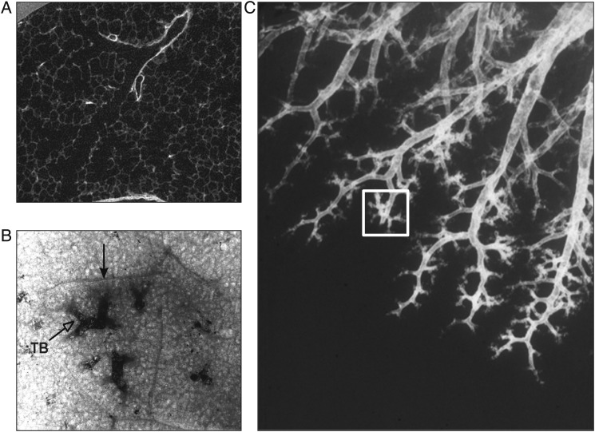

B : Bronchogramme d’un poumon humain post mortem où un groupe de bronchioles terminales est entouré par un septa de tissu conjonctif fibreux pour former un lobule pulmonaire secondaire. C et A : lobule tel que défini par Reid10, où le motif de ramification passe de celui où les branches sont espacées de quelques centimètres à celui où les branches du carré ne sont séparées que de quelques millimètres..

Figure 1 : B : Bronchogramme d’un poumon humain post mortem où un groupe de bronchioles terminales est entouré par un septa de tissu conjonctif fibreux pour former un lobule pulmonaire secondaire. C et A : lobule tel que défini par Reid10, où le motif de ramification passe de celui où les branches sont espacées de quelques centimètres à celui où les branches du carré ne sont séparées que de quelques millimètres.

### Emphysème

Syndromes de chevauchement Comme préalablement évoqué, il existe différentes formes mixtes associant d’autres entités pneumologiques et l’emphysème pulmonaire. Il est par ex. question de «combined pulmonary fibrosis and emphysema» (CPFE) en présence d’une association de fibrose pulmonaire et d’emphysème pulmonaire. La forme mixte associant asthme et BPCO (avec ou sans emphysème pulmonaire) est appelée «asthma-COPD-overlap» (ACO).


### Dilatation Des Bronches - DDB

### Bronchiolite Chronique

### Fibrose Pulmonaire

### Sarcoidose

### Lobectomie - Pneumectomie

### HTAP

### SDRA

### OAP

#### Phatologies Restrictives

#### Pathologies Obstructives

Les pathologies respiratoires obstructives comme l’Asthme et la Bronchite Chronique Obstructive sont un enjeu de santé publique. L’asthme est une inflammation chronique des bronches, entrainant leur hyperréactivité à certaines substances. La maladie se manifeste par des crises, sous forme de sifflements et de gênes respiratoires. Dans les cas les plus graves, ces crises peuvent nécessiter une hospitalisation. Les dernières enquêtes nationales montrent une prévalence cumulée de l’asthme de plus de 10 % chez l’enfant âgé d’au moins dix ans et une prévalence de l’asthme actuel de 6 à 7 % chez l’adulte. En 2006, sont survenus 1038 décès par asthme en France. Après un pic observé dans les années 1980, la mortalité par asthme a diminué. Cette diminution est également observée chez les enfants et adultes jeunes. Selon les données du PMSI, on dénombre, en 2007, 54 130 séjours pour asthme dont plus de la moitié chez des moins de 15 ans. Entre 1998 et 2007, le taux annuel standardisé d’hospitalisation pour asthme a diminué. Les données sur les recours aux urgences permettent de documenter d’importantes variations saisonnières des exacerbations d’asthme (1-3). L’Asthme Aigu Grave (AAG), forme particulièrement grave d’épisodes aigus des crises d’asthme, représente entre 8 000 et 16 000 hospitalisations par an en France. Elle nécessite une ventilation dans 13% des cas. La mortalité est en diminution mais reste non négligeable avec 1 500 à 2 000 morts par an soit 4 pour 100 000 habitants en 1990 contre 5,75 en 1970, associé à des conséquences médico-économiques lourdes. (6). La Bronchite Chronique Obstructive (BPCO) est une cause majeure de mortalité et d’incapacité dans le monde entier. Deux aspects anatomiques sont caractéristiques de la maladie : l’obstruction des bronches et les destructions du parenchyme pulmonaire. Le diagnostic de BPCO ne peut être posé qu’après mesure de la fonction respiratoire par des Explorations Fonctionnelles Respiratoires (EFR) qui identifient un rapport expiratoire maximal seconde/capacité vitale (VEMS/CV) < 70% ; ceci après inhalation de bronchodilatateur. A la différence, la bronchite chronique est définie par la présence d’une toux productive durant 3 mois, pendant 2 années consécutives, mais sans retentissement sur la fonction respiratoire (8). En moyenne, 5 à 15% des adultes dans les pays industrialisés ont une BPCO définie par spirométrie. En 1990, on considérait que la BPCO occupait la douzième place mondiale en tant que cause de mortalité et d’invalidité combinées, mais on s’attend à ce qu’elle devienne la cinquième cause d’ici 2020. (7). Selon l’INSERM en 2000, on estimait à 1,7 million le nombre de personnes atteintes de BPCO en France, soit 4,1% de la population. Cette proportion monte à 7,5% chez les plus de 40 ans. La maladie est plus fréquente chez les fumeurs, le tabac étant le principal facteur de risque. De par le développement du tabagisme féminin, la BPCO concerne aujourd’hui presque autant de femmes que d’hommes. En 2013, environ 145 000 personnes atteintes de formes sévères de la maladie bénéficiaient d’une oxygénothérapie de longue durée (associée ou non à un traitement par ventilation). La BPCO entraine en outre chaque année de nombreuses hospitalisations et des décès liés aux exacerbations de la maladie (poussées d’aggravation des symptômes habituels). En 2013, entre 95 000 et 145 000 hospitalisations liées à la maladie ont été comptabilisées en France, et environ 16 000 décès par an, en moyenne, ont été enregistrés sur la période 2000-2011. La mortalité associée à la maladie stagne malgré les progrès de la prise en charge, probablement en raison d’un sous-diagnostic de la maladie ou de diagnostics trop tardifs. (9-10).

# Deuxième Partie - Modèle de Poumon

## Physiologie pulmonaire

### Physiologie pulmonaire :

Les deux poumons font partie de l’organe de la respiration mais jouent également un rôle important d’épuration et de protection vis-à-vis de l’environnement avec lequel ils sont en contact aérien permanent. Objectif du poumon est d’oxygèné le sang et d’évacuer le CO2. La fonction principale des poumons est de permettre à de l’O2 contenu dans l’air ambiant de pénétrer dans le sang veineux mêlé et de permettre à du CO2 provenant du sang veineux mêlé d’être rejeté dans l’air ambiant. Cette fonction d’hématose peut être divisée en deux mécanismes. Premièrement, la mécanique ventilatoire correspond à l’ensemble des structures et mécanismes qui permettent un acheminement de l’air extérieur vers les alvéoles, ainsi que le renouvellement du gaz alvéolaire. Deuxièmement, la diffusion alvéolocapillaire qui décrit l’échange à travers la membrane alvéolocapillaire de l’oxygène et du dioxyde de carbone. Il s’apparente à une membrane de transfert mais avec de nombreux compartiements les alvéoles, au nombre de 500 milions chez l’homme. Cette compartiementation crée un éloignement entre l’air ambiant et la zone de transfert. Ainsi, le poumon génère sa grande surface de diffusion en se divisant en un multitude d’unités. Le débit sanguin et le consommation d’oxygène crée un pompe à oxygène (qui “aspire” l’O2). Cette poly-compartiementation du poumon permet d’augmenter la surface déchange dans un espace réduit donc d’optimiser les transferts des gaz. Cette surface d’échange est comprise entre 50 et 100 $m^{2}$ soit 85 $m^{2}$ en moyenne. Cette particularité du poumon permet également de s’adapter au besoin en optimisant les approts en fonction des besoins, mobilisation de réserve. L’hétérogénité de foncitonnement des différents compartiement ou territoire entraine une réduction de son efficacité. L’homogénéisation de fonctionnement optimise l’efficacité du poumon, sa rentabilité. C’est clairement ce qui ce passe pour le rapport ventilation-perfusion. La grande hétérogénéité du rapport ventilation perfusion entraine une baisse des capacités d’extraction de l’O2, avec un sang veineux melé au sortir du poumon plus bas que si le poumon fonctionne de façon plus homogène. L’hétérogénéité s’applique pour la pefusion pulmonaire, la ventilation, le rapport ventilation-perfusion mais également aux propriétés de diffusion locale. Le soufflet pulmonaire avec la ventilation de ce dernier permet l’évacuation du CO2.

Inspiration active L’entrée de gaz dans les poumons, ou « inspiration », est un mécanisme actif qui résulte de la contraction des muscles des voies aériennes supérieures et de muscles dits inspiratoires. Le principal muscle inspiratoire est le diaphragme, innervé par les nerfs phréniques. Des muscles accessoires sont stimulés conjointement, notamment les muscles intercostaux externes et les scalènes. Leur contraction permet de rigidifier la cage thoracique et d’éviter son affaissement lors de la contraction du diaphragme. (3) La contraction de ces différents muscles permet ainsi une distension de la cage thoracique et une diminution de la pression qui règne dans la cavité pleurale. Cela provoque l’augmentation du volume des poumons et diminue la pression régnant dans les alvéoles ; de l’air est aspiré dans les alvéoles dès que la pression alvéolaire devient inférieure à la pression atmosphérique.

Expiration passive sauf lors de détresse respiratoire La sortie de gaz, ou « expiration », est le plus souvent un phénomène passif, lié à la restitution de l’énergie élastique accumulée par le système ventilatoire au cours de l’inspiration. Dans certaines circonstances comme l’exercice physique ou l’obstruction bronchique sévère, des groupes musculaires tels que les muscles abdominaux ou intercostaux internes contribuent à l’augmentation de la pression pleurale et, par conséquent, de la pression alvéolaire ; l’expiration est alors dite active. Le poumon est élastique et revient passivement à son volume pré-inspiratoire au cours de la respiration de repos.

Le volume d’air insipiré (qui entre dans les poumons) est légèrement plus élévé que le volume d’air expiré car la quantité d’oxygène absorbée est légèrement supérieur à celle du CO2 élminié.

Les gaz gagnent un côté de l’interface sang/gaz par les voies aériennes et le sang gagne l’autre côté par les vaisseaux sanguins.

### Ventilation

Les voies aériennes : Les voies aériennes sont divisés en deux groupes,une zone de condution et une zone transitionnelle et repiratoire. La zone de condution débute par la traché suivi de bronche souche puis de muliple division associé à une réduction de qualibre de bronchioles au fur et à merue que l’on pénètre dans le poumon. La zone de conduction n’étant pas en contacte avec les alvéoles, elle ne participe pas au échange gazeux et forme lespace mort anatomique. Son volume est d’environ 150 mL environ. Ce volume peut être calculé à l’aide de la mesure de la concentration en CO2 dez gaz expiré. La région où s’effectuent les échanges corresond à la zone respiratoire composé des alvéoles mais également des bronchioles respiratoire des conduits alvéolaires et des sacs alvéolaires, formant une unité anatomique appelée acinus. L’air inspiré descend jusqu’aux bronchioles terminale par un mouvement de masse, comme l’eau dans un tuyau. Au-delà, la surface tansversale globale des voies aériennes atteint une telle taille, en raison du grand nombre de ramifications, que la vélocité du gaz vers l’avant diminue considérablement. La diffusion est le principale mécanisme de ventilation dans la zone respiratoire.

C’est la ventilation avléolaire est un paramètre essentiel correspondant à la quantité d’air frais disponible et en contacte pour les échange gazeux. La distribution de la ventilation varie également entre la base et le sommet en fonction de la gravité et donc de la position du patient. Ce phénomène peut être expliqué par la compliance. Il est en effet intéressant de rappeler qu’une alvéole pulmonaire déjà distendue va être moins sensible aux variations de pression et pourra ainsi difficilement accumuler plus d’air. Inversement, une alvéole moins distendue pourra rapidement augmenter de volume pour une même variation de pression. Lorsque le patient est debout, le poumon est entrainé vers le bas par gravité, tirant ainsi sur la plèvre au niveau de l’apex. La pression pleurale est alors plus négative à l’apex qu’à la base et les alvéoles sont donc plus distendues. De ce fait, elles sont moins compliantes à l’apex qu’à la base et sont moins bien ventilées. Ce principe reste vrai si le patient est en décubitus latéral ou dorsal. Ainsi, en décubitus latéral gauche par exemple, le poumon droit sera moins bien ventilé. En décubitus dorsal, la partie postérieure des poumons sera la mieux ventilée. (8) Les zones inférieurs du poumon sont mieux ventilées que les zones supérieures. Lors d’un test par inhalation qu Xénon-133, la ventilation par unité de volume est plus importante vers le bas du poumon et diminue au fur et à mesure que l’on s’élève. On retrouve les mêmes résultats quelque soil la position du sujet, mais les inégalité et le gradient de ventilation change de position. Ainsi en décubitus dorsal, la ventilation basale et apicale retrouve une ventilation identique, mais le gradient de ventilation se fait du haut vers le bas. De même, en décubitus latéral, le poumon situé vers le bas est le mieux ventilé.

Perfusion pulmonaire - débit sanguin pulmonaire Hétérogénéité de perfusion - de débit sanguin en fonction de la localisation dans le poumon. Contôle actif de la circulation avec une vasoconstriction pulmonaire hypoxique lors de la baisse de la PO2 alvéolaire (hypoxie dans l’environnement des artères, avec de nombreux médiateur). Le mécanisme n’est pas encore clairement identifié.

### Diffusion

Rapport ventilation-perfusion La ventilation et la perfusion pulmonaire ne sont pas homogènes mais varient principalement en fonction de forces gravitationnelles et donc de la position du patient. L’augmentation de la ventilation vers les bases est cependant moins importante que l’augmentation de la perfusion, si bien que le rapport entre la ventilation est la perfusion augmente de la base vers le sommet.

Lois de diffusion La diffusion d’un gaz à travers un tissu est régie par la loi de Fick: la diffusion est proportionnelle à la surface du tissu (S: 50 à 100 m2 pour la barrière alvéolo-capillaire) et inversement proportionnelle à l’épaisseur (E: 0,5 $\mu m$ pour la barrière alvéolo-capillaire) de ce tissu; elle est aussi proportionnelle au gradient de concentration ( ou de pression: P1 - P2) de part et d’autre du tissu; elle est enfin proportionnelle à une constante de diffusion (D) qui tient compte des caractéristiques du gaz (cette constante est proportionnelle à la solubilité du gaz (Sol) et inversement proportionnelle à la racine carrée de son poids moléculaire (PM). Cette constante de diffusion est 20 fois plus élevée pour CO2 que pour O2.
$$\dot{V}_{gaz} \sim \frac{S}{E}.D.(P_{1}-P_{2})$$
où
$$D \sim \frac{Sol}{\sqrt{PM}}$$

Caractéristique du poumon :

```
* Ventilation : Compliance et Résistance
* Pefusion : Débit sanguin pulmonaire
* Rapport $\.{Q}/\.{V}$
* Diffusion : Sufrace d'échange et Coefficient de Diffusion
```

[10] La compliance pulmonaire ($C_{l}$) et la résistance ($R_{l}$) à l’écouelement de l’air sont des mesures fondamentales de mécanique respiratoire permettant de caractériser l’état du poumon.

La compliance pulmonaire est le rapport entre le changement de volume des poumons d’un patient et la variation de la pression alvéolaire [1]. Alors que la compliance pulmonaire peut changer aux cours du cycle respiratoire, les valeurs moyennes de $C_{l}$ sont de 0.12 à 0.20 L / cmH2O (200 mL/cmH2O) chez les adultes bonne santé [2] et peuvent augmenter ou diminuer de manière significative en réponse aux affections pulmonaires obstructives [3], [4]. La resistance pulmonaire est le rapport entre le débit d’air sous pression et le débit d’air dans les voies respiratoires et est généralement de 3.6 à 4.2 cmH2O / L / s chez les adultes en bonne santé et beaucoup plus élevé chez les sujets atteints de pneumopathie obstructive [5],[6]. Comme mesures agrégées des propriétés mécaniques du poumons, $C_{l}$ et $R_{l}$ jouent un rôle important dans la formule du capnogramme du patient, la forme d’onde de la pression partielle du dioxyde de carbone dans l’air expiré en fonction du temps (capnographie temporelle) ou en fonction du volume expiré (capnographie volumétrique) [7]. Des études antérieures ont montré une relation entre les caractéristiques du capnogramme et les modifications de la compliance et de la résistance pulmonaires, le déséquilibre ventilation-perfusion et l’inhomogénéité pulmonaire [7]-[9]. De plus, les chercheurs ont utilisé les caractéristiques du capnogramme pour distinguer les sujets sains des sujets atteints de maladie pulmonaires [10],[11].

[11]

[12] : La structure du modèle présentée dans cet article est basée sur la physiologie et les paramètres du modèle ont des significations physiques claires. Comme tout modèle est basé sur des hypothèses, l’analyse du modèle doit être considérée dans ces limites. Une hypothèse est que les alvéoles peuvent être modélisées par un nombre limité de compartiments. Ceci est une simplification évidente, car les voies respiratoires humaines se composent de millions d’alvéoles. Celles-ci peuvent toutes avoir des propriétés différentes en termes de vidange ainsi que des taux d’échange de gaz et de ventilation-perfusion. Une autre hypothèse du modèle est que les tensions de CO2 alvéolaires et artérielles sont équilibrées. Par conséquent, toute limitation de la diffusion du CO2 sur la membrane capillaire alvéolaire est négligée. Bien que ces hypothèses puissent être justifiées dans des circonstances physiologiques normales, elles peuvent être moins valables dans les états pathologiques.

[3] : Inégalité ventilatoire en série et en parallèle (page 16). La vitesse de vidanve d’une region est détreminée par sa constante de temps qui est le produit de la résistance de sa voie aérienne (R) par sa compliance (C). Plus grande est la constante de temps (RC), plus longue sera la vidange. Ce mécanisme est décrit comme une inégalité de ventilation en parallèle dans le cardre d’une différecne de résistance entre deux régions ventilées par obstruction partielle des voies aéreinnes (bronchioles). Un autre mécanisme appelé inégalité de ventitation en série créer par des dilatations des voies aériennes périphériques qui provoquent des différences de ventilation le long des segments bronchiques desservant les unités pulmonaires. Ces régions mal ventilé par diminution de la diffusion des gaz inspirés compte tenu de l’atteinte des bronchioles terminale, se viderons en dernier.

[6] Une inégalité ventilation-perfusion est inévitable dans les BPCO, et ceci entraine une hypoxémie avec ou sans rétention de CO2. Typiquement, le patient de type A a seulement une hypoxémie modérée (entre 60 et 70 mmHg) et une PaCO2 normale. Par opposition, le patient de type B a une hypoxémie souvent sévère (entre 40 et 50 mmHg) avec une PaCO2 augmentée, surtout à un stade avancé de la maladie. La différence alvéolo-artérielle pour la PO2 est toujours augmentée, en particulier chez les patients souffrant d’une bronchite chronique sévère. Augmentation à la fois de l’espace mort physiologique et du shunt physiologique. L’espace mort est plus spécialement augmenté dans l’emphysème, alors que des valeurs élevèes de shunt sont particulièrement courante au cours de la bronchite chornique.

A l’effort, la PO2 artérielle peut augmenter ou diminuer, selon les variations de la ventilation et du débit cardiaque, et les modificaitons dans la distribution de la ventilation et du débit sanguin. Chez quelques patients, le facteur principal de la chute de la PaO2 est une limitation du débit cardiaque ce qui, en présence d’une inégalité ventilation-perfusion, majore l’hypoxémie. Les patients qui ont une rétention de CO2 présentent souvent des valeurs de PaCO2 plus élevées à l’effort, en raison de la limitation de leur réposne ventilatoire.

La lésion essentielle de l’emphysème centroacinaire est une dilatation des bronchioles respiratoires au milieu de l’acinius, ce qui est certainement une anomalie morphologique qui peut engendrer des inégalités en série.

Les effets délétères de l’obstruction des voies aériennes sur les échanges gazeux sont limités par la ventilation collatérale qui se produit chez ces patients. Des conduits de communication existent normalement entre les avléoles adjacentes et entre les petites voies aériennes voisine, fait provué expérimentalement. Chez ces patients, le faible débit sanguin allant aux unités non ventilées met en valeur l’efficacité de la ventilation collatérale, puisque certaines voies aériennes sont vraissemeblablement complétement fermées, en particulier dans la bronchite sévère. La vasoconstriction hypoxique et un autre facteur qui réduit l’importance de l’inégalité ventilation-perfusion. Cette réponse locale à une PO2 alvéolaire basse diminue le débit sanguin destiné aux régions faiblement ou non ventilées, minimisant l’hypoxémie artérielle. Lorsque des patients ayant une BPCO reçoivent des bronchodilatateurs, par un exemple du Sablutamol, une légère chute de la PaO2 se produit parfois. Ceci est probablement dû à l’action vasodilatatrice de ces médicaments qui augmente le débit sanguin des alvéoles faiblement ventilés. Ces constations sont encore plus nettes dans l’asthme.

[13] : L’hypoxémie artérielle est fréquente dans l’asthme. Elle est provoquée par une inégalité du rapport venitation-pefrusion (VA/Q). L’inégalité de ventilation est largement démontrée aussi bien par la méhtode en apnée que par la méhtode du rinçage sur plusieurs cycles. De plus, les mesures avec le xénon radioactif montrent des régions hypoventilées, en particulier lorsqu’elles sont recherchées par l’enregistrement du débit d’entrée ou sortie du gaz. Des inégalités marquées de distribution du débit sanguin sont également observées, avec typiquement des réductions transitoires concernant des zones différentes à des moments différents. L’espace mort physiologique et le shunt physiologique sont généralement tous les deux anormalement évevées. Un exemple de ditribution des rapports veniltation-perfusion montre chez un asthmatique présentant des symptômes modérés, présente une distribution franchement différente d’une distribution ventilation-perfusion normale. Elle montre une distribution bimodale avec une part très importante (environ 25%) du débit sanguin total qui va aux uintés à bas rapport VA/Q (environ à 0.1), ce qui rend compte de l’hypoxémie modérée du patient. Après avoir bénéficié d’un aérosol bronchodilateur avec diminution du bronchospasme associée à une diminution des résistances respiratoires, une modification des rapport ventilation-perfusion apparait. Le débit sanguin allant aux alvéoles à bas VA/Q augmente de 25 à 50% du débit total avec comme conséquence une baisse de la PaO2. Le mécanisme de l’augmentation de l’hypoxémie semble être une levée de la vasonconstriction dans les zones faiblement venitlées. La chute de la PaO2 est associée à une augmentation de l’espace mort et du shunt physiologique. En pratique, les effets favorables de ces médicaments sur les voies aériennes excèdent de loin les desavantages d’une hypoxémie modérée supplémentaire.

## Modèle mathématique de poumon

Modèle mathématique le plus simple fréquemment utilisé est le modèle *monocompartiemental*. Modèle connu et utilisé depuis longtemps, le flux d’air est proportonnel à la différence de pression entre la pression alvéolaire $P_{A}$ et la pression à la bouche $P_{atm}$. La constante de proportionnnalité correspond à la résistance $R$ de l’arbre bronchique à l’écoulement. Cette résistance dépend de la dimensions du tube (longueur et surface) et de la viscosité du fluide. Plus le tube est long et fin plus il est difficile de faire passer de l’air dans ce dernier. On peut exrpimé cela par une équation correspondant à la Loi de Poiseuille :

$$P_{atm}-P_{A}=R\dot{V}$$

Par ailleurs le volume du « ballon » dépend de l’élastance des tissus (notée E) et des forces qui lui sont appliquées (ici la pression alvéolaire $P_{A}$ et la pression $P$ exercée par le diaphragme). Cela s’exprime par une autre équation traduisant l’équilibre élastique du ballon :

$$P_{A}-P=EV$$

On en déduit en combinant les deux équations, un modèle décrivant l’évolution du volume du ballon au cours tu temps :

$$P_{atm}-P=R \dot{V}+EV$$

Il s’agit d’une équation différentielle puisqu’elle fait intervenir à la fois le volume $V$ et sa variation $\dot{V}$, linéaire, et on sait en calculer explicitement la solution.

# Troisième Partie - Capnographie

## Histoire de la capnographie

En 1620, le chimiste belge Van Helmont décrit pour la première fois la molécule CO2. En 1754, le Dr Black publie dans sa thèse que le CO2 est expiré dans l’air. Le CO2 est considéré comme toxique et mortel jusqu’en 1824. Il faudra attendre l’américain Henderson en 1925 pour démontrer l’intérêt physiologique du dioxyde de carbone dans le métabolisme. En 1928, le CO2 est associé aux narcotiniques dans les anesthésies humaines, mais les patients convulsaient au réveil, raison pour laquelle cette méthode a été abandonnée. Luft développe le principe de la capnométrie pendant la seconde guerre mondiale en partant du principe que le CO2 est un gaz qui absorbe les rayons infrarouges[16][17]. Il dépose deux brevets en 1943 pour des applications pratiques cliniques : usine de caoutchouc et surveillance environnementale dans les sous-marins. C’est en 1950 qu’Etan et Liston introduisent le concept de monitorage du CO2 expiré pendant l’anesthésie par absorption des infrarouges. Les rayons IR sont absorbés par tous les gaz composés de plus de deux atomes par molécule, ou par deux atomes différents lorsque la molécule est composée d’uniquement deux atomes. Cependant, à cause du poids, du volume et du coût, ces appareils ne sont pas utilisés en clinique courante. Puis une méthode de capnographie basée sur la spectrographie photoacoustique est développée au Danemark. Elle repose sur la détection au microphone des sons produits par la lumière pulsée en fonction des longueurs d’onde des IR. Le spectromètre de masse, basé sur la séparation des gaz en fonction de leur masse moléculaire, peut, de façon séquentielle, échantillonner tous les gaz inspirés et expirés. Au début du XXe siècle, les chercheurs ont exploré la nature de la courbe expiratoire du dioxyde de carbone, y compris les composants physiologiques comme l’espace mort et les gaz alvéolaires, autant par la méthode de capnographie standard (temporelle) qu’avec la capnographie volumétrique par échantillonnage séquentiel rapide du volume de gaz(1)[18]. Dans les années 1950 et les années 1960, les premières études ont examiné la forme de la courbe de capnographie normal et ont recherché aux niveaux du CO2 alvéolaire un modèle utilisant des équations de dilution dépendantes du temps (2)(3)[19][20]. Cependant, ce n’est qu’en attendant la disponibilité des systèmes commerciaux des analyseurs infrarouges rapides que la détermination de la pression partielle du dioxyde de carbone dans la respiration a pu passer du laboratoire de recherche de physiologie au « chevet » du patient(4)[21]. Cette technologie a d’abord trouvé une application dans l’anesthésie et plus tard aux soins intensifs pour un nombre limité d’indications. Ce n’est que récemment que cette technologie a fait son apparition dans d’autre spécialité comme les urgences s’ouvrant à de nouvelles applications cliniques. C’est à la fin des années 1950 que les chercheurs ont commencé à appliquer des approches tout d’abord manuelles puis informatiques pour l’ajustement du dioxyde de carbone et l’étude des courbes d’écoulement. Ces courbes de CO2 en fonction du temps encore appelées capnographie standard et rapporté au volume expiré encore appelées capnographie volumétrique ont permis l’estimation de paramètres ventilatoires comme la PCO2 alvéolaire (5)[22]. Ces travaux ont été initialement entrepris avec des méthodes manuelles consommant du temps (6)[23] puis ont été rapidement suivis par des méthodes analogiques (5)[22], analogiques / numériques combinés (7)[24] et, plus tard, avec des données numériques coûteuses et complexes (8)[25]. Les premiers capnographes s’appuyaient sur des méthodes électroniques analogiques pour déterminer les paramètres de la fréquence respiratoire (FR) et de la pression partielle de CO2. L’introduction du microprocesseur au début des années 1970 a conduit à des logiciels basés sur la mesure de la fréquence respiratoire et de la PETCO2, avec un fabricant intégrant le CO2 et le volume pour calculer la ventilation alvéolaire et l’élimination du dioxyde de carbone. Cependant, malgré le développement de technologie informatique pour identifier et classer les changements en temps réel du capnogramme dès la fin des années 1980 (9)(10)[26][27], les algorithmes logiciels des dispositifs commerciaux ne permettent pas à l’heure actuelle l’analyse de la courbe en clinique courante. Ces dispositifs restent concentrés sur une estimation robuste du taux de CO2 en fin d’expiration (PETCO2) et de la fréquence respiratoire.

## Technique d’enregistrement de capnographie

### Détection du CO2 expiré

Il existe différents systèmes pour détecter et analyser le CO2 expiré.

#### La spectrométrie de masse (11)[17]

Elle est basée sur le concept de séparation des ions en fonction de leur poids moléculaire et de leur charge. Il existe deux types de spectromètre de masse, celui à secteur magnétique et détecteurs fixés et le quadripôle. Un champ électrique charge les molécules de gaz et les transforme en cations qui seront accélérées et analysées. Cette technique a pour avantages d’analyser plusieurs gaz en même temps, et voir le CO2 expiré de plusieurs patients en même temps dans différentes salles opératoires (maximum 31). Mais le spectromètre de masse est un appareil volumineux et cher qui ne trouve pas son utilité au pied du lit du malade.

#### La spectrographie Raman

Elle a été inventée en 1928 par Mr Raman. Un rayon laser d’argon monochromatique de haute intensité traverse un échantillon de gaz. Les molécules de gaz dispersent la lumière avec des longueurs d’ondes caractéristiques, qui sera collectée par des lentilles. Différents filtres sélectionnent alors la lumière en fonction des gaz mesurés. Le nombre « d’impacts » par 100 ms est utilisé pour déterminer la concentration des gaz. Cette technique permet une analyse multi gaz, rapide.

#### Méthode colorimétrique

Il s’agit d’une méthode récente peu utilisée en raison de l’absence d’un monitoring continu et d’affichage graphique des variations de CO2. C’est un système qui détecte la présence de CO2 dans un gaz à l’aide d’un papier filtre ou un autre révélateur sensible au pH.

#### La spectrophotométrie d’absorption infrarouge

La spectrophotométrie par rayonnement infrarouge (IR) est la technique de capnographie actuellement la plus utilisée en médecine (11)[17]. Un faisceau IR traverse un mélange gazeux, l’intensité de la lumière transmise est fonction de la longueur de la cellule d’absorption, de la pression partielle du gaz et de son coefficient d’absorption. Chaque gaz absorbe plus spécifiquement une longueur d’onde donnée, il est donc possible de mesurer l’absorption d’un gaz spécifique, qui sera proportionnelle à la concentration. Le CO2 absorbe les IR à une longueur d’onde de 4.3 µm. En comparant la différence d’absorption d’un rayonnement IR qui traverse deux cellules (une dont la concentration en CO2 est connue, l’autre dont la concentration reste à mesurer), il est possible de mesurer la concentration en CO2 du mélange.

### Système d’analyse de l’ETCO2

On distingue deux types de système d’analyse de l’ETCO2 (12)[28].

#### Système non aspiratif : « Mainstream »

Le système non aspiratif, mainstream, où la mesure est effectuée directement sur le flux gazeux du circuit respiratoire du patient, permet de fournir une analyse rapide et sans distorsion de la concentration en CO2. La mesure se fait en continu, sans décalage temporel. L’inconvénient de ce système réside dans le fait que le capteur alourdit le dispositif et risque de modifier la position de la sonde d’intubation chez les patients en ventilation invasive.

#### Système aspiratrif : « Sidestream »

Le système sidestream est un système aspiratif où l’échantillon de gaz est aspiré à débit constant à travers un tube fin pour être analysé par une cellule de mesure. Le débit aspiratif est de 150ml/min. Il permet une analyse multi gaz en utilisant plusieurs longueurs d’ondes. Ce capnographe a l’avantage d’être léger mais les sécrétions pulmonaires et l’eau de condensation ont tendance à obstruer le tube d’analyse. Toute fuite sur le circuit provoque une aspiration d’air ambiant et crée une mesure anormalement basse du CO2 expiré. Par ailleurs, le délai d’analyse de l’ETCO2 est allongé. Les progrès technologiques ont permis de faire un système microstream, qui est un système aspiratif amélioré où le CO2 transite par une fine tubulure avant d’atteindre la chambre de mesure. Ce dispositif permet de diminuer le temps d’analyse et permet ainsi une synchronisation entre flux expiré et courbe capnographique.

Actuellement les systèmes de mesure sont compacts, petits, légers et faciles d’utilisation. Pour une utilisation clinique, les capnomètres doivent pouvoir mesurer une concentration de CO2 dans une gamme de 0 à 10 % (76 mmHg). La précision avec un système IR est d’environ 0.2%, ce qui est suffisant en clinique. Les résultats sont faussés par la présence de protoxyde d’azote ou d’oxygène mais le système est conçu pour annuler automatiquement ces biais. Par ailleurs, les variations de température ambiante et de pression atmosphérique peuvent intervenir sur les résultats de concentration en CO2 notamment sur les systèmes sidestream.

## Capnographie et pathologie respiratoire

Il existe deux types de capnogrammes, soit il s’agit d’une mesure du CO2 expiré en fonction du temps (capnographie temporelle ou standard), soit les mesures sont réalisées en fonction du volume expiré (courbes SBT-CO2 ou capnogramme volumétrique).

### La capnographie temporelle ou sandard

Le terme « capnographie standard », c’est-à-dire la capnographie basé sur le temps, se réfère généralement au tracé du dioxyde de carbone en fonction du temps par opposition à la capnographie en fonction du volume expiré volumétrique appelé « capnographie volumétrique » où la phase inspiratoire de la courbe n’est pas représentée. Les deux formes d’onde sont subdivisées en trois phases expiratoires avec une quatrième inspiratoire pour la capnographie standard) (13)(14)[29][30] *figure 1*:

- Phase I : appelée base inspiratoire, elle correspond à la vidange de l’espace mort anatomique, la pression partielle en CO2 est proche de 0 puisque le mélange gazeux de cet espace n’a pas été en contact avec les échanges gazeux alvéolaires. Sa composition est comparable à celle de l’air inspiré avec peu ou pas de CO2.
- Phase II : de montée expiratoire, on observe une augmentation rapide du CO2 expiré, sous forme d’une courbe sigmoïde, correpsondant à la transition entre l’espace mort anatomique et l’arrivée des gaz alvéolaires. Durant cette étape, le gaz de l’espace mort anatomique est remplacé par le gaz alvéolaire. La verticalité de la phase II est en faveur d’une distinction nette entre l’espace mort anatomique et l’air alvéolaire. L’élimination de l’air alvéolaire est normalement synchrone, ce qui est prouvée par l’ascension soudaine de cette phase (14)[30].
- Phase III : on parle de plateau expiratoire, provenant de la vidange séquentielle des volumes alvéolaires. Elle correspond à l’expiration du CO2 provenant uniquement des alvéoles. Cette phase est en plateau voir légèrement ascendant et varie en fonction des pathologies respiratoires. Une majoration de la pente correspond à une vidange asynchrone des alvéoles lors de l’expiration, ce qui est visible dans les pathologies obstructives comme l’asthme et la BPCO. La fin du plateau correspond à la PETCO2, affichée sur les écrans de monitoring. La PETCO2 est un reflet de la pression artérielle en CO2 chez un sujet sain avec un métabolisme stable.
- Phase 0 : c’est l’inspiration d’un gaz dépourvu de CO2 qui provoque une chute brutale du CO2 jusqu’à la ligne de base (c’est-à-dire 0 mmHg). A la phase 0 succède la phase I. Néanmoins, il est parfois difficile de faire la distinction entre fin d’expiration et début d’inspiration.

Les phases II et III sont séparées par un angle alpha, décrit dans la littérature, dont la norme est comprise entre 100° et 110°. Cet angle augmente lorsque la pente de la phase III s’accentue et que la phase II présente une croissance plus progressive. L’angle beta sépare les phases III et 0, il est proche de 90°. Il permet d’estimer l’importance du phénomène de réinhalation. C’est ainsi que les différentes phases se succèdent sur le capnogramme, au fil des mouvements respiratoires. L’analyse du capnogramme est un élément important dans la surveillance du patient, aussi bien pour les valeurs numériques que pour l’analyse des quatre phases et de la modification de l’aspect des courbes (14)[30]. Il existe deux vitesses de balayage des courbes. Une lente, avec une vitesse de 25 mm/min, qui montre les tendances générales de la concentration en CO2 expiré. Une rapide, qui défile à 12.5 mm/sec soit 750 mm/min, et qui permet l’analyse des détails d’un cycle respiratoire.

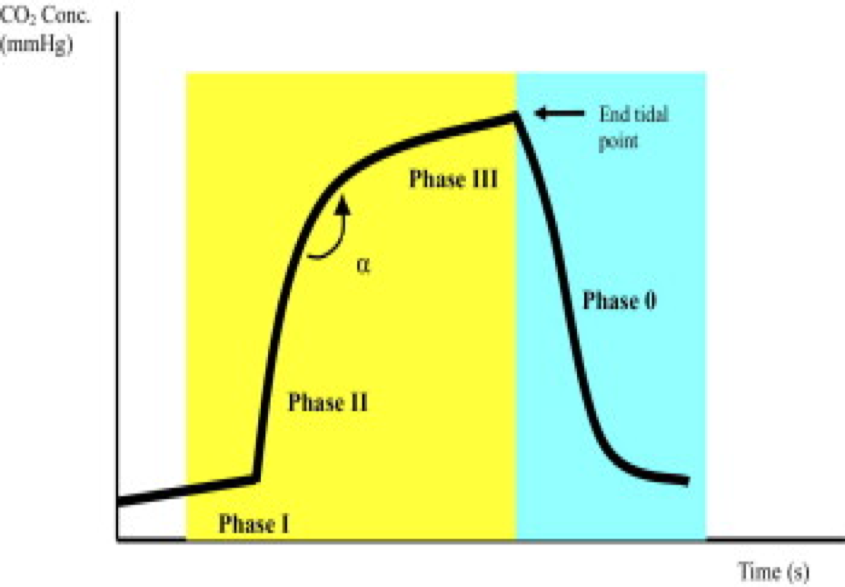

Courbe de Capnographie Standard et ses différentes phases.

### Capnographie Volumétrique

La capnographie volumétrique correspond à la PCO2 mesurée et exprimée en fonction du volume lors de la phase d’expiration. La terminologie utilisée pour les différentes phases, les transitions de phase, les angles et les pentes sont similaires pour la capnographie standard et la capnographie volumétrique. Le capnogramme volumétrique a été subdivisé en volume pour chaque phase (15)[31] et associé à des fonctions (16)[32] pour mieux caractériser et de manière plus fiable la forme d’onde ainsi que produire des estimations dérivées avec une plus grande reproductibilité. L’analyse de la courbe de capnographie volumétrique permet d’estimer un certain nombre de mesures physiologiques et physiquement interprétables de la fonction respiratoire, telles que l’espace mort anatomique et l’espace mort physiologique ainsi que le rapport des deux, l’élimination du CO2 et le flux sanguin capillaire pulmonaire. Ces mesures permettent de découvrir de nombreux troubles cardio-respiratoires comme le syndrome de détresse respiratoire aiguë, la BPCO, l’asthme et l’embolie pulmonaire. Ces paramètres morphologiques, qui divisent le capnogramme volumétrique en phases I-III (17)[33], permet une caractérisation et une interprétation accrues du capnogramme volumétrique à l’aide d’un certain nombre de caractéristiques dérivées. L’un des intérêts de cette analyse est de permettre une mesure substitutive non invasive pour l’espace mort anatomique, l’espace mort des voies aériennes, estimé par la méthode de Fowler (18)[34] qui utilise les parties centrales ‘’ linéaires’’ ajustées en phase III (par exemple, 40 à 80% du volume expiré) et la phase II. Cette mesure permet de calculer l’espace mort des voies respiratoires sur une base respiratoire pour chaque patient plutôt que de compter sur la règle plus approximative de 1 mL/kg d’espace mort en fonction du poids. Brewer et al. (19)[35] a constaté que cette règle, dérivée des moyennes de population, par rapport à l’espace mort mesuré de la voie aérienne, ne présentait aucune corrélation (r2 = 0,0002). Au fil du temps, les chercheurs s’inquiètent de l’effet des variations de mesure sur les estimations du volume de l’espace mort de la méthode Fowler et de la variation résultante de ces paramètres calculés. Cela a conduit au développement de méthodes à faible dispersion, qui comprenaient l’ajustement du volume expiratoire de CO2 par rapport à la courbe de volume expiratoire entre 40 et 80% du volume expiré en utilisant des polynômes de première, seconde et troisième ordre (20)[36]. Plus récemment, un ajustement rapide du capnogramme volumétrique à l’aide d’une approximation fonctionnelle déterminée avec un algorithme non linéaire de moindres carrés a été utilisé (16)[32], ce qui a entraîné une diminution de la variabilité respiratoire intra-patient ainsi que la dispersion des paramètres calculés. Les caractéristiques discutées dans cette section sont destinées à être interprétées en utilisant des concepts physiologiques ou cliniques connus.

Espace Mort Physiologique - $V_{D_{phys}}$
$$V_{D_{phys}}=V_{D_{aw}}+V_{D_{alv}}$$

Equation de BOHR : Christian Bohr a été le premier à décrire l’espace mort en 1891. Correspond au rapport du Volume de l’Espace Mort Physiologique ($V_{D_{phys}}$) par rapport au volume courant $V_{T}$
$$\frac{V_{D}}{V_{T}}=\frac{(P_{A}CO2-P\overline{E}CO2)}{P_{A}CO2}$$

Equation de ENGHOFF : Enghoff a remplacé la $P_{A}CO2$ par la $P_{a}CO2$, cette simplification pratique et brillante est devenu la méthode de référence au lit du malade. Néamoins, elle reste une technique invasive avec la nécessité d’une gazométrie artérielle pour recueillir la valeur de $P_{a}CO2$. En considéréant que la $P_{A}CO2$ est égale à la $P_{a}CO2$ on en déduit :
$$\frac{V_{D}}{V_{T}}=\frac{(P_{a}CO2-P\overline{E}CO2)}{P_{a}CO2}$$

Equation de FLETCHER : L’introduction de VCap par Fletcher et al. ont encore simplifié la mesure clinique de l’espace mort. Fletcher et al. [16] [33] suggèrent que PACO2 pourrait théoriquement être obtenu à partir de la partie médiane de la phase III du capnogramme volumétrique, une idée confirmée par la suite par Breen et al. Heureusement, le concept d’obtention de PACO2 à partir de la moitié de la phase III a récemment été validé par rapport à la technique d’élimination multiple des gaz inertes (MIGET) [19][38]. Maintenant que cette limitation majeure a été surmontée, il est possible d’obtenir des mesures fiables et de manière non-invasive, de l’espace mort physiologique (VDPhys) par Capnographie Volumétrique (VCap). Bien que la plupart des méthodes actuelles s’appuient sur l’approche géométrique de Fowler, la forme du capnogramme peut grandement affecter sa précision. Par conséquent, de nouvelles approches mathématiques ont été proposées pour améliorer la robustesse de la détermination de VDaw [35][39]. Une fois que VDphys et VDaw sont connus, VDalv se calcule facilement en soustrayant simplement VDaw de VDphys.

### Pathologies respiratoires et courbes de capnographie

L’analyse des données fournies par la capnographie doit être réalisée de manière systématique. Une variation de la PETCO2 doit tenir compte des modifications de la forme du capnogramme et des trois éléments qui interviennent sur la PETCO2, à savoir la production métabolique de CO2, son transport en fonction du débit sanguin et son élimination par la ventilation.

#### Intubation oesophagienne

Affirmer que la sonde d’intubation se trouve dans la trachée est souvent difficile, et l’auscultation pulmonaire ne permet pas toujours de faire la part des choses, notamment chez les sujets obèses. C’est pourquoi la vérification de la position de la sonde par le suivi de la courbe de capnographie est devenue une pratique courante en pré-hospitalier et en anesthésie(21)[40]. En cas d’intubation oesophagienne, on observera soit l’absence de courbe de capnographie, soit quelques courbes dont l’amplitude va décroître progressivement. Quand celles-ci sont visibles, elles reflètent le gaz entré dans l’estomac lors de la ventilation non invasive au BAVU, ou l’ingestion au préalable de traitements anti-acides, carbonatés ou effervescents créant une réaction chimique avec production de CO2 intra-gastrique. Mais ce CO2 est rapidement évacué par la ventilation, provoquant une chute de l’EtCO2 et un aplatissement des courbes. Il est donc recommandé d’attendre 6 cycles respiratoires avant de confirmer l’intubation endotrachéale.

#### Intubation sélective

La bronche souche droite forme un angle de 25° avec la trachée, elle est donc pratiquement dans son axe, ce qui explique que dans la majorité des cas d’intubation sélective accidentelle, la sonde se trouve dans la bronche droite. Lors d’une intubation sélective, il existe deux phénomènes. Le premier est lié à une augmentation de l’espace mort, un élargissement du gradient alvéolo-artériel en CO2 et une baisse de la PETCO2. Le second est une diminution de la ventilation alvéolaire, une augmentation de la PaCO2 et donc de la PETCO2 au niveau de la bronche non intubée(21)[40].

#### Embolie pulmonaire (22)(23)[41][42]

L’embolie pulmonaire augmente l’espace mort alvéolaire, entraînant une diminution du CO2 expiré par dilution et par conséquent une PETCO2 inférieure à des valeurs normales. Le gradient alvéolo-artériel et par conséquent la P(a-ET)CO2 augmente. Plusieurs études ont été menées pour discuter de l’intérêt de la mesure du CO2 expiré dans le diagnostic de l’embolie pulmonaire(13)(22)[29][41]. Une des pistes de travail est d’exclure ce diagnostic quand le patient a une probabilité clinique faible et un gradient P(a-ET)CO2 normal malgré des D-dimères positifs. Mais plus récemment, c’est l’aire sous la courbe de capnographie qui est utilisée pour diagnostiquer l’EP. Celle-ci diminue quand le diagnostic est confirmé. L’aire moyenne sous la courbe de patients ayant une EP est d’environ la moitié moindre de celle des patients sains. Ces données suggèrent qu’un patient présentant des symptômes pouvant évoquer une EP avec courbe de capnographie ayant une faible aire sous la courbe doit être considéré comme étant à haut risque.

#### Trouble ventilatoire obstructif : Asthme et BPCO

L’asthme se caractérise par une hyperréactivité bronchique, une inflammation et un remodelage bronchique (24)[43]. On observe essentiellement une diminution du calibre des voies aériennes appelée obstruction bronchique. Le bronchospasme modifie l’allure du capnogramme avec une augmentation de la pente en phase III. Le bronchospasme entraîne une diminution de la ventilation alvéolaire sans diminution de la perfusion pulmonaire ce qui diminue le rapport ventilation-perfusion (V/Q). Or, la réduction de diamètre des bronches n’est pas homogène dans l’ensemble poumon, certaines zones étant plus spastiques que d’autres, de ce fait on assiste également à une diminution du rapport V/Q alvéolaire local. On parle d’hétérogénéité en parallèle du rapport V/Q alvéolaire(25)[44]. Cela cause une déformation du capnogramme marquée par une (14)[30] *figure 2*:

- Diminution de la verticalité en phase II
- Ouverture de l’angle alpha
- Augmentation de la pente en phase III

Dans les cas sévères, cette courbe prend une forme triangulaire. La pente en phase III et l’angle alpha sont associés au degré de sévérité de la crise d’asthme, plus ceux-ci sont importants, plus le bronchospasme est majeur (26)[45]. Des études ont montré que l’ETCO2 des patients faisant une crise d’asthme est plus bas que les sujets sains (35)(26)[46][45]. Dans ce contexte la PETCO2 n’est plus le reflet de la pression alvéolaire en CO2 du fait d’un trapping alvéolaire important. On observe une augmentation du temps expiratoire, ce qui entraîne une augmentation du gradient P(a-ET)CO2. Une étude américaine a montré que le rapport dCO2/dt, qui reflète la pente du plateau alvéolaire du capnogramme, permet de détecter l’obstruction bronchique(27)[47]. L’auscultation pulmonaire avec la recherche de sibilants ne permet pas toujours de prédire la présence ou non d’une obstruction bronchique, et la sévérité des sibilants n’est pas forcément corrélée au diamètre des voies aériennes, d’où l’intérêt d’une mesure objective (28)[48]. Krauss et al.(29)[49] ont montré dans les troubles obstructifs de type asthme et BPCO, une déformation de la courbe de capnographie caractéristique en forme d’« aileron de requin » ou « shark’s fin » en anglais. Ces modifications chez les malades de pathologie pulmonaire obstructive (BPCO et asthme) sont marquées par une courbure importante [5][50], [10][51], [11][52] et résulte de l’arrivée décalée du gaz alvéolaire [3][53]. Ces modifications de courbe chez les patients obstructifs étaient corrélées aux altérations retrouvées lors des mesures de spirométrie. Comparativement, il y a peu de données sur la morphologie du capnogramme chez les patients présentant une insuffisance cardiaque aiguë ou d’autres maladies pulmonaires restrictives.

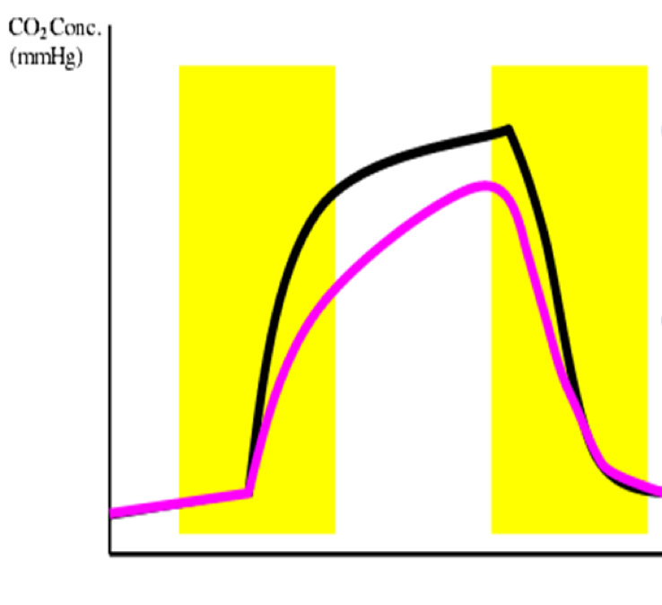

Courbe de Capnographie Standard normale (en noir) et pahtologique (en rose).

## Analyse d’article - Bibliographie sur la Capnographie

### Utility of the expiratory capnogram in the assessment of bronchospasm [47]

En 1996, Yaron et al. (27) ont conduit une étude prospective au service des urgences en vue d’étudier l’intérêt de l’utilisation de la courbe de capnographie pour l’évaluation du bronchospasme chez des patients asthmatique. Cette étude incluait 20 patients asthmatiques et 28 patients sains. L’objectif de ce travail était de voir si la pente du plateau alvéolaire (pente de phase III ou dCO2 / dt) du capnogramme pouvait servir comme mesure non invasive du bronchospasme et était indépendant de l’effort contrairement aux mesures de spirométries. Les valeurs de Débit Expiratoire de Pointe (DEP), approche standard pour évaluer l’obstruction des voies respiratoires aux urgences, et dCO2 / dt ont été mesurées pour chaque sujet ainsi qu’avant et après traitement bronchodilatateur. La mesure de la pente du plateau alvéolaire dCO2 / dt était réalisée sur un cycle de cinq expirations régulières consécutives avec un moyennage des valeurs pour chaque patient. Ils ont conclu que la dCO2 / dt était une mesure indépendante de l’effort, rapide et non invasive permettant une évaluation du bronchospasme chez les patients souffrant d’asthme sévère. Ce paramètre était fortement corrélé au DEP (r = 0,84, p < 0,001). Les résultats montraient également une modification du DEP et de la dCO2 / dt après traitement par bronchodilatateur. Le DEP passait de 58 à 74% (p < 0.001) et de 0.27% à 0.19% (p < 0.005) pour la dCO2/dt. Druck et al. (31), travaillant avec Yaron, ont cherché à prolonger ce travail en examinant la relation entre les modifications de DEP et le changement de pente de la phase III en capnographie volumétrique pour des mesures enregistrées avant et après bronchodilatateur. Le pourcentage de changements entre le DEP et son substitut était associé à une forte corrélation (r = 0.7, p < 0.2, n = 13). Comme pour le travail de You et al., cette recherche définit un nouveau paramètre pour analyser le capnogramme pour des patients asthmatiques. Cependant, la mesure de cet indice a été réalisée manuellement avec un risque d’erreur important et une difficulté pour son application en clinque courante.

### Expiratory capnography in asthma - evaluation of various shape indices [50]

Une des premières études fondamentales dans l’analyse de la capnographie a été conduite par You et al (30). Ils ont examiné de nouveaux paramètres en fonction des pentes et des ratios de surface pour mieux caractériser la nature de la transition de la phase II à la phase III en capnographie standard. Les corrélations entre indices capnographiques et mesures spirométriques ont été calculées chez 10 sujets sains et 30 patients asthmatiques de sévérités différentes. Huit indices descriptifs ont été évaluée en mesurant leur reproductibilité et leur sensibilité sur l’évaluation de l’obstruction des voies aériennes. Trois indices mesurais la pente de la courbe lors de la phase d’expiration (S1, S2 et S3). Un index composite SR correspondant au ratio entre les pente de la partie 1 et 2 de l’ascention du CO2 (S2/S1)x100 a été évalué. Un ratio de surface AR correspondant au rapport des surface A1 et A2, surface au-dessus d’un seuil de 2.5 % de CO2 entre 0.2 et 1 seconde (AR : (A1/A2) x100), a été calculé. Trois derniers indices ont été utilisé correspondant à la deuxième dérivée de la courbe de capnographie au niveau des segment S1, S2 et S3 (SD1, SD2 et SD3). Les résultats ont montré qu’une grande différence de corrélation parmi l’ensembles des indices. Selon leur recherche, une haute sensibilité à l’obstruction de voie aérienne a été vue pour des pentes intermédiaires et terminales (S2 et S3) ainsi que pour le radio des pentes (SR), suivie par les indices associés à la dérivées secondes de la courbes (SD1, SD2, SD3). La corrélation la plus forte a été retrouvée entre le VEMS%-pred et le pic de dérivée seconde SD2 associé à une corrélation r = 0.93 (p < 0.01). Les corrélations les plus faibles ont été retrouvé pour les indices S1 et AR. Cette recherche a permis de mettre en évidence des paramètres simples et utilisables, ainsi qu’une corrélation forte entre indice de capnogrpahie et données spirométriques. Mais ces paramètres restent du domaine temporel sans anlayse dans le domaine fréquentiel. Il est à noter également que les mesures ont été réalisées manuellement associé à un facteur d’erreur non négligeable, aussi consommateur de temps avec une reproductibilité médiocre. Ce travail reste néanmoins malgré quelques points discutables, une référence dans l’analyse de la capnographie.


### Capnogram Shape in Obstructive Lung Disease [49]

Krauss et al., du *service des urgences du “Children’s Hospital” à Boston*, ont inclus deux cent soixante-un patients sur 15 mois dans cette étude. Cents dix patients présentaient un syndrome obstructif dont 49 étaient considérés comme sévère, 60 un syndrome restrictif et 91 patients étaient sans pathologie pulmonaire. Ce travail prospectif incluaient des rectutés via le service d’exploration foncitonnelle, chez des patients bénéficients d’une exploration par spirométrie avec un état pulmonaire stable. Les enregistrement de capnographie ont été réalisé à l’aide d’une canule orale-nasale (prélèvement du CO2 du nez et de la bouche) à un moniteur multiparamètre portable (Medtronic LIFEPAK®12, Redmond, WA) avec captage de flux latéral à faible débit (Microstream®). Cette technique de capnographie recueille un échantillon continu d’air à un débit de 50 mL / min et enregistre la concentration de CO2 instantanée toutes les 40 ms soit une fréquence de 25 Hertz. Un échantillon de 90 s, contenant au moins 8 respirations spontanées, a été prélevé pour chaque patient. Les mesures spirométriques standard, y compris le VEMS et la capacité vitale forcée, ont été réalisées immédiatement après les enregistrements de la capnographie. La catégorisation diagnotique des patients ainsi que le degré de sévérité de l’atération de la fonction pulmonaire a été confirmé par un pneumologue indépendant après lectures des données spirométriques. L’analyse des courbes de capnographie a été réalisé à l’aide d’un algorithme informatique, capable d’identifier automatiquement et de mesurer systématiquement les principales caractéristiques du capnogramme. Les données brutes ont été utilisées et analysées selon les étapes suivantes. L’analyse des courbes de capnographie a été ralisé après cyclage de la coubres, respiration par respiration. Le repérage des cycles respiratoires a été réalisé à l’aide de la pente et de l’amplitude de la concentration en CO2 permettant de repérer la fin de l’expiration et le début de l’inspiration. Les différentes phases du capnogramme ont été identifiés : les phases d’élévation expiratoire initiale et le plateau alvéolaire. Leur pentes mesurées en mmHg/s ont été calculées à l’aide d’une regression linéaire et les angles associés à l’horizontale ont été calculés. La concentration d’ETco2, la fréquence respiratoire et les temps inspiratoires et expiratoires ont également été déterminées pour donner un ensemble de six valeurs caractéristiques pour chaque respiration (valeur ETco2, fréquence respiratoire, angle de décollage, angle d’élévation, temps inspiratoire et temps expiratoire). Les valeurs médianes de chaque paramètre ont été utilisées pour l’analyse réduisant l’influence des valeurs aberrantes. Les valeurs médianes, à leur tour, ont été moyennées sur tous les sujets appartenant au même groupe ventilatoire. Les moyennes de chaque groupe ont été comparées par paire pour en évaluer les différences statistiquement significatives à l’aide de la méthode de comparaison multiple de Tukey-Kramer. Les résultats montre une différence entre les moyennes des paramètres des populations des patients obstructifs vis à vis des patients normaux et/ou restrictifs. Ces différences sont plus marqués pour les angles de montée expiratoire initiale et du plateau alvéolaire (l’angle de décollage et l’angle d’élévation). Ces différences étaient progressives, augmentant avec la gravité du syndrome obstructif (*figure n° 3 & 4*). Pour l’angle de montée expiratoire initiale une différence statistiquement significative a été retrouvé seulement entre les patients présentant un syndrome obstructif sévère et les patients présentant une syndrome obstructif modéré, les patients normaux et restrictifs. Le groupe des patients présentant un syndrome obstructif modéré ne présentait pas de différence avec les groupes de patients normaux ainsi que des groupes des patients restrictifs. Pour l’angle du plateau alvéolaire, l’ensemble des comparaisons entre groupe, hors mis celle des normaux versus restrictif, étaient significativement différent. L’angle moyen de décollage de la phase ascendante du capnogramme pour le groupe des patients obstructifs sévères était de 7,2 degrés de moins (IC 95% : 4,0-10,4) par rapport à l’angle de décollage pour le groupe des patients normaux. L’angle d’élévation moyen du plateau alvéolaire était de 0,8 degré de plus (IC 95%: 0,14-1,4) pour le groupe des patients obstructifs modérés par rapport au sujets avec spirométrie normale, tandis que l’angle d’élévation moyen était de 3,6 degrés de plus (IC à 95%: 2,9-4,3) pour le groupe des patients obstructifs sévère que pour les sujets avec spirométrie normale. L’angle du plateau alvéolaire semble plus sensible pour distinguer les syndromes obstructifs. Aucune comparaison de groupe associant les deux angles n’a été réalisé.

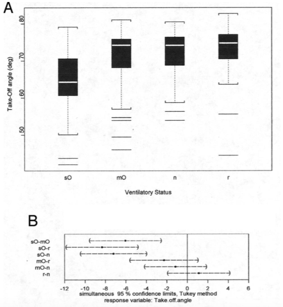

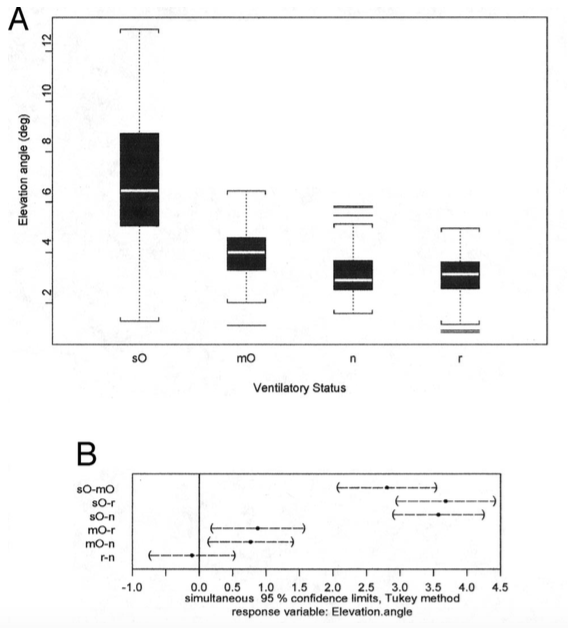

Angle du plateau alvéolaire pour chaque groupe avec intervalles de confiance. A, angle d’élévation par rapport à l’état ventilatoire. B, différences ventilatoires appariées, angle d’élévation. sO = maladie pulmonaire obstructive sévère (DO), mO = OD modérée, n = normale, r = maladie pulmonaire restrictive.

### Correlations between capnographic waveforms and peak flow meter measurement in emergency department management of asthma [44]

hisamuddin et al. ont étudié l’intérêt de la capnographie chez des patients en crise d’asthme aiguë se présentant aux services des urgences du centre hospitalier uinversitaire de Sains en Malaysie. Ce travail portait sur la comparaison et la corrélation entre la mesure spirométrique de Débit Expiratoire de Pointe (DEP) réalisé à l’arrivée aux urgences et des paramètres de la courbe de capnographie. Les critères d’inclusions étaient une dyspnée associée à des antécédents d’asthme connu chez des patients adultes. Tous les patients présentant un doute diagnostic ont été exclus. Les patients ont tous bénéficiés d’un examen clinique et d’une spirométrie par DEP pour évaluer la sévarité de la crise, ainsi que d’une prise en charge standard de la pathologie asthmatique. Les patients présentant un état de gravité instable nécessitant une prise en charge immédiate ainsi que les patients BPCO ont été exclus également. Pour chaque patient trois mesures du DEP ont été enregistrées à l’aide du Wright’s Mini Peak Flow Meter®. La mesure la plus élevée des trois a été pris en compte pour l’analyse. Elle a été exprimer en pourcentage de la théorique attendue basé sur l’âge, la taille et le sexe. Les courbes de capnographie ont été enregistré à chaque phase de l’étude avant et après traitement par un capnographe Novametrix Capnogard®, fabriqué aux États-Unis, avec une fréquence de mesure de 48 fois par seconde soit 48 Hz, par intervale de 0.02s. Les formes d’onde ont été jugées adéquates/conformes lorsqu’au moins trois formes d’onde de morphologie régulière, sans artefacts significatifs, ont été observées. Les enregistrements de DEP et capnographie ont été ralisés avant et après traitement pour chaque patient. Les paramètres d’analyse étudiés sur la courbe de capnographie étaient : la pente de phase 2 (appelé “pente”), la pente de phase 3 (appeler “plateau”) et l’angle $\alpha$ corresondant à l’angle formé par les pentes de phase 2 et 3. La pente de la phase 2 a été mesurée pendant 0,25 s à partir du premier point où le CO2 mesuré dépassait 4 mmHg. La pente de la phase 3 a été mesurée entre la 0,75s et la 0,25 s (soit un temps total 0,5 s ) à partir du point de fin d’expiration. Tous les capnographes des patients avaient trois lectures permettant de recueillir trois valeurs pour la pente et le plateau, et trois valeurs de $\alpha$ ont été calculées. La moyennes des trois valeurs a été pris en compte pour l’analyse. Une analyse statistique a été effectué à l’aide d’un test t appariés pour la comparaison des moyennes, une corrélations simples et canoniques pour déterminer les corrélations et un test des rangs signés Wilcoxon pour l’analyse des données catégoriques. Au total 128 patients ont été inclus dont 8 non pu être retenu compte tenu d’une mauvais qualité de courbe de capnographie et 16 n’ayant pu ralisé un DEP post traitement. Seulement 100 patients ont été analysés, agée en moyenne de 35.2 ans (12-71 ans) en majorité des homme (56%). Trente pourcent ont bénéficié d’un aérosol de Sablutamole simple, 53% ont eu un aérosole d’Ipratropium associé au premier traitement et 17% ont eu en plus de ces deux première mesure un bolus de 200 mg d’Hydrocortisone. Sur les 100 patients inclus dans l’étude, 63% (n = 63) avaient un DEP <50% de la valeur théorique attendu à l’admission; 26% (n = 26) un DEP entre 50 et 80% et seulement 11% (n = 11) avait un DEP à plus de 80% de la théorique. Après traitement 87 patients ont pu sortir du services des urgences et 13 ont nécessité encore 24h de surveillance. Aucun n’a nécessité de prise en charge en soins intensifs. Une différence significative entre les DEP avant et après traitement a été retrouvé (p <0,001). Concernant l’EtCO2 aucune différence significative n’a été retrouvé entre le pré et le post traitement (p=0.871). La pente de phase 3 avaient une moyenne de 0,44 (IC 95%: 0,33-0,47) avant traitement et une moyenne de 0,23 (IC 95%: 0,21-0,28) après le traitement. Cette réduction était nettement significative (p < 0,001). L’angle $\alpha$ a été calculé avait une moyenne en prétraitement de 134,36 (IC 95%: 129,53-138,74) était significativement plus élevée que la moyenne en post-traitement de 123,27 (IC 95%: 121,25-127,96 ) (p < 0,001). Concernant la pente de phase 2 aucune différence significative n’a été retrouvée entre le pré et le post traitement. De faible correlation ont été retrouvé entre le DEP et les indices graphiques des capnogrammes quelques soit la période avant ou après traitement avec des coefficients de corréltation < 0.6. Aucune comparaison des indices graphiques de capnographe, entre les différents groupes de sévérité d’asthme n’a été ralisé. Ce travail a permis une évaluation de la capnographie en situation réel aux urgences chez des patients en crise d’asthme aiguë, ce qui n’est pas le cas de bon nombre d’étude sur le sujet. Plus souvent des patients stables sont recrutés pour ces analyses. Une des qualités de cette études, en plus de travailler sur des patients situation instable, est de réalisé une études avant après traitement. Les patients sont leurs propres témoins ce qui démontre une forte preuve de concepte. C’est la première étude de ce type. L’analyse de forme d’onde capnographique est relativement nouvelle et n’a pas encore prouvé sa capacité à détecter les changements dans les voies aériennes du patient asthmatique. Théoriquement, les débits de pointe sont plus associé au fonction des voies respiratoires de plus grands diamètres, tandis que le volume expiratoire maximal en 1 s (VEMS) et le VEMS / capacité vitale forcée (CVF) reflètes les voies respiratoires plus petites. Le FEV1 et le FEV1 / FVC sont techniquement difficiles à réaliser aux urgences et impliquent des équipements encombrants contrairement au DEP.

### Segmented Wavelet Decomposition for Capnogram Feature Extraction in Asthma Classification [54]

Pomares et al. (40) décrivent une méthode pour évaluer la gravité de l’asthme en utilisant l’extraction de caractéristiques à partir de la décomposition des ondelettes du tracé de capnographie (41). Ces caractéristiques ont été déterminées par la décomposition en segments de la forme d’onde (le versant ascendant, le plateau et le versant descendant). Une fenêtre de 3 pixels est utilisée pour approximer la courbe par une droite par interpolation linéaire. Les pentes des 4 segmenter de la courbe en A-B, C-D, E-F, G-H ont été analysés. Une fois cette première étape réalisée, 4 signaux ont été extraits permettant une analyse par transformé en ondelette à l’aide successivement de filtre passe haut et passe bas associé à une échantillonnage descendant. Dans le même temps une analyse utilisant une ondelette mère de Haar " de frome carré " a été réalisé permettant la détermination des coefficients d’ondelettes. Cette dernière était associé à une analyse multi-résolution par segments en fonction de la transformation en ondelettes. En utilisant un classificateur de machine vectorielle de support (SVM) avec un noyau de fonction Gaussian Radial Basis, les coefficients d’entrée pour chaque capnogramme ont été classés dans l’une des six classes de gravité. Le vecteur caractéristique le plus performant comprenait l’association des segments ascendant et descendant du capnogramme avec une sensibilité et une spécificité respectivement de 100% et 91,43%, en utilisant l’ensemble de données complet pour les tests, polarisant ainsi les résultats rapportés. Les meilleurs sensibilité spécificité retrouvé lors de l’analyse d’un seul segment était de 55,7% et 99,4%, et correspondait au segment G-H du plateau de la courbe. L’analyse, à l’aide de l’ondelette mère de Haar, retrouvait une sensibilité et spécificité de respectivement 88,6% et 100% très proche de l’analyse associant deux segments de la courbe. L’utilisation de la transformation en ondelettes permet de sélectionner les caractéristiques permettant d’optimiser l’analyse de la courbe et la classification des niveaux de sévérité. Cette étude a été mené à Cuba sur 23 patients présentant un asthme de modéré à sévère.

Segmentatoin de la courbe : Pour réaliser la segmentation, le signal de capnogramme est converti en une fonction de pentes. Tout d’abord, une fenêtre glissante est définie, ayant une largeur égale à 3 échantillons, ce qui correspond au nombre minimal d’échantillons de segment de signaux utilisés dans les expériences. Deuxièmement, à l’aide de la fonction Matlab poly fit, les échantillons de l’intervalle de la fenêtre sont ajustés sur un segment de ligne et sa pente est calculée. La fenêtre est décalée d’un échantillon à chaque fois jusqu’à ce que tout le signal ait été traité. Troisièmement, une courbe de pente en fonction de l’indice de pente est construite. À partir de cette courbe, les cycles respiratoires sont d’abord déterminés en identifiant les points de pente négative minimale correspondant à la fin de l’expiration. Les segments A-B, E-F et G-H sont ensuite identifiés. Le segment A-B est constitué de points sur la même pente partant du point de pente minimum. Le segment E-F correspond à des points de la même pente partant du point de la pente maximale. Le segment G-H est identifié comme la ligne allant de la fin de l’expiration au point où la valeur de la pente change au-dessus de 0,01. Une fois que les segments sont identifiés, les intersegments sont identifiés le long d’ensembles d’échantillons entre les segments.

Transformée en ondelettes : Ensuite, pour chaque type de segment, le nombre d’échantillons a été normalisé à une moyenne calculée sans tenir compte du nombre minimal ou maximal d’échantillons pour ce segment dans le signal. La transformation en ondelettes a ensuite été appliquée aux segments. De cette manière, le même nombre de coefficients d’ondelettes a été obtenu par type de segment. Après la procédure précédente, les valeurs moyennes des coefficients d’approximation et de détail du troisième niveau de décomposition - CA3, CD3, CD2 et CD1 - ont été sélectionnées comme caractéristiques, CA3 étant les coefficients d’approximation du troisième niveau de décomposition et CD3, CD2 et CD1. détailler les coefficients de décomposition des niveaux 3, 2 et 1. L’expérience a également été menée à l’aide de la transformée en ondelettes de Haar. Le nombre de coefficients d’ondelettes a été considérablement réduit lorsque la décomposition en ondelettes a été appliquée (restreinte) aux segments d’intérêt. Pour 6803 échantillons de capnogramme, par exemple, les coefficients détaillés du premier niveau de décomposition ont été réduits entre 3402 à 2110, ce qui équivaut à une réduction de 40%. Le pourcentage de réduction était similaire pour les coefficients restants.

### Feature extraction of capnogram for asthmatic patient [55]

Kean et al. ont étudié les coubres de capnographie de patients asthmatiques et non asthmatique présentant une détresse respiratoire consultant au service des urgences du Penang Hospital, pour tanter de les différencier. L’enregistrement des courbes a été réalisé à l’aide d’une canule naso-buccale par monitorage continu. Le matériel utilisé pour ces enregistrement étaient un capnographe *Nihon Kohden Bedside Monitor BSM-2301K* permettant une extraction numérique des données à partir d’un PC. Au total 34 patientes ont pu être analysés et enregistrés, dont 18 étaient des patients non-asthmatiques et 16 étaient asthmatiques. Un prétraitement a été effectué par lissage de la courbe pour réduir le bruit à l’aide de la fonction *“Curve Fitting Tool”* du logiciel MATLAB. L’analyse a été réalisé respiration par respiration ou encore capnogramme par capnogramme. Les paramètres analysés étaient à la fois des paramétres proposés par des études précédentes et de nouveaux paramètres proposés. Les paramètres déjà connus étaient ceux proposés par You B. et al [50] : S1, S2, S3, SR, A1, A2 et AR (comme décrits plus haut). Ils ont été recueillis et calculés exactement de la même manière que décrits dans l’étude de You B. et al.

```
  * L'Activité est l'écart type quadratique de l'amplitude de la forme d'onde.
  * La Mobilité est le calcul de l'écart-type de la pente par rapport à l'écart-type de l'amplitude.
  * La Complexité, donnant une mesure de détails excessifs en référence à la forme de courbe "la plus douce" possible, l'onde sinusoïdale, correspondant à l'unité.
```

Les paramètres Hjorth ont été extraits du capnogramme sur deux parties du capnogramme. Tout d’abord, ils ont été extraits sur tout le cycle du capnogramme, nommé HP1. Deuxièmement, les paramètres de Hjorth ont été extraits sur une partie du capnogramme allant du T1 (ou le CO2 est égal à la moitié de la valeur de l’EtCO2) jusqu’au temps correspondant à l’EtCO2, nommé HP2.

### Investigation of capnogram signal characteristics using statistical methods [57]

Les modifications du capnogramme de différentes maladies ont amené les chercheurs à analyser ce signal pour différencier les maladies des voies aériennes, tout particulièrement pour distinguer les asthmatiques et des non asthmatiques [6-9]. Cependant, de nombreuses études antérieures réalisées manuellement se sont basées sur l’hypothèse que le capnogramme est un signal stationnaire. Ces analyses basées sur cette hypothèse sont limitées à l’utilisation de certaines méthodes classiques dans le domaine temporel, qui supposent que le contenu du signal est constant dans des intervalles de temps différents. Cependant, la plupart des signaux physiologiques sont considérés comme étant non stationnaires, ce qui signifie que la distribution de probabilité conjointe de ces signaux change lorsqu’ils sont décalés dans le temps. En conséquence, des paramètres tels que la moyenne et la variance changent avec le temps ou la position. Ainsi, les informations variables dans le temps sont utiles. Jusqu’à présent, aucune tentative n’avait été faite pour analyser les propriétés du capnogramme. Par conséquent, une enquête sur les caractéristiques du signal semblait nécessaire pour comprendre la nature des signaux de capnogramme et de les utiliser pour distinguer avec précision différents types de maladies des voies respiratoires. Dans cette étude, Kazemi et al. nous présentent une méthode statistique pour étudier les propriétés du signal capnogramme. Dans cette méthode, la distribution de probabilité de premier ordre et toutes les fonctions de probabilité conjointe sont calculées pour trouver leur dépendance à l’égard du temps. Les 3 phases de l’étude qui consistent en l’acquisition des données, le prétraitement et l’analyse des propriétés des signaux de capnogramme sont présenté dans la partie méthode. Dans cette étude Kazemi et al. ont enregistré sur 51 patients consultants pour dyspnée aux urgences des courbes de capnographies. Trente et un patients avaient un diagnostic d’asthme et 20 présentaient une pathologie autres. Ces enregistrement étaient réalisée par voie nazale ou buccale à l’aide d’un capnographe *CapnostreamTM20 Model CS08798*. Acquisition des données Pour chaque patients la durée d’enregistrement étaient d’environ 5 minutes avec une fréquence d’échantillonnage de 200Hz. L’analyse a été effectuée sur les 5 cycles respiratoire en continue présentant le moins d’artéfact soit environ une durée de 20 secondes. Prétraitement Après cette première étape de sélection des données, un prétraitement des données a été effectué pour éliminer le bruit inutile. Une méthode de filtrage par moyenne mobile a été utilisée pour lisser la courbe en raison de sa simplicité et de son efficacité, en particulier pour éliminer les bruits de haute fréquence dans les signaux. Cette méthode lisse les données en remplaçant chaque point de données par la moyenne des points de données voisins définis dans une plage spécifique. Ce processus équivaut à un filtrage passe-bas. Une grande plage augmente le lissage mais avec une diminution de la résolution. Inversement une petite plage diminue l’effet de lissage mis préserve la résolution. La valeur optimal de la fenetre de filtrage dépend de l’ensembles des données et nécessité évaluation. Ici une fenetre de filtrage de 13 a été retenu car elle correspodait au meilleur compromis entre lissage et résolution. De plus ce choix a été justifié par le calcul des coefficient de corrélation entre courbe native et courbe filtré avec un coefficient égal ou supérieur à 0.99.

Analyse de propriétés des signaux de capnographie Un processus aléatoire stationnaire est caractérisé par une condition d’équilibre dans laquelle les propriétés statistiques sont invariantes dans le temps [15]. Cela signifie que la distribution de probabilité du premier ordre est indépendante du temps. De même, toutes les fonctions de probabilité conjointe sont également invariantes par rapport à un décalage d’origine temporelle; c’est-à-dire que les distributions de probabilité conjointes du second ordre ne dépendent que de la différence de temps (m-n). Un processus aléatoire stationnaire est un processus dans lequel les statistiques dérivées des observations sur les membres de l’ensemble à deux instants distincts sont les mêmes. Par conséquent, un processus stationnaire pourrait être dans l’une de ces catégories [17]: * processus aléatoire stationnaire de premier ordre; que les statistiques de premier ordre, moyenne ($m_{x}$) et variance ($\sigma_{x}^{2}$), sont invariantes dans le temps. * processus aléatoire stationnaire de second ordre; que la statistique du second ordre, l’autocorrélation ($\varphi_{xx}$), dépend tout au plus des différences de temps (m-n) et non des deux valeurs m et n. * processus aléatoire stationnaire au sens large; que la moyenne des statistiques du premier ordre et l’autocorrélation des statistiques du second ordre sont invariantes dans le temps. Par conséquent, un processus considéré comme étant stationnaire de second ordre est également stationnaire au sens large. * processus aléatoire strictement stationnaire; que tous les moments et moments articulaires possibles sont invariants dans le temps. Donc, si un processus aléatoire est strictement stationnaire, il doit être stationnaire pour toutes les minuscules.

### Frequency analysis of capnogram signals to differentiate asthmatic and non-asthmatic conditions using radial basis function neural networks [58]

### New Prognostic Index to Detect the Severity of Asthma Automatically Using Signal Processing Techniques of Capnogram [59]

Kazemi et al. (38) (39) ont recueilli des enregistrements de capnographie sur canule nasale pour 73 patients asthmatiques et 23 non asthmatiques provenant du service des urgences. Les enregistrements comprenaient une durée de 5 minutes chacune avec une fréquence d’échantillonnage de 200Hz. Dans un second temps une sélection de 5 cycles respiratoires consécutifs sans artéfact correspondant à environ 20 secondes a été réalisé pour chaque patient. Une variabilité inter-respiration significative était statistiquement retrouvé sur la moyenne et la variance conduisant l’auteur à caractériser le signal de capnographie comme non stationnaire. À partir du capnogramme, les caractéristiques ont été extraites en utilisant différentes façons de représenter des signaux non-stationnaire : dans le domaine temporel, avec un codage prévisionnel linéaire (LPC) et dans le domaine fréquentiel, avec un modèle autorégressif associé à une transformé rapide de Fourier pour représenter la densité spectrale de puissance (PSD). La capnographie étant un signal biomédical lié à la respiration et donc de la catégorie des signaux basse fréquence, les auteurs ont choisis une fenêtre de Blackman de longueur M = 256 associé à la transformé rapide de Fourier (FFT). Ce choix n’a pas affecté la résolution temporelle du signal. À partir des caractéristiques extraites, cinq caractéristiques (toutes avec des AUC individuels > 0,7) ont été sélectionnées pour la classification, y compris 2 coefficients LPC, et, à partir du PSD, la première composante de fréquence ainsi que l’amplitude et nombre total de composants de la bande de fréquence ont été sélectionnés. En utilisant les cinq caractéristiques des capnogrammes de patient asthmatiques et non asthmatiques, la classification par une ANN avec comme sortie unique la gravité de l’asthme, a montré que la détection rapportée et le taux d’erreur étaient respectivement de 90,15 et 9,85%. Dans cette études les auteurs ont rapporté une différence significative du nombre de composante spectrale et de leur amplitude de la FFT entre les patients asthmatiques et non asthmatiques. Le profil spectral des patients asthmatiques présentait deux pics principaux contre un seul pour les patients non asthmatiques. La fréquence de ces pics principaux ainsi que leur bande passante étaient différente entre ces deux populations. Le premier des pics principaux avait une fréquence associée à une bande passante pour les patients asthmatiques resperctivement de 0.078 Hz et 0.23 Hz contre 0.04 Hz et 0.08 Hz respectivement pour les non asthmatiques. L’ensemble des paramètres (magnitude, fréquence et bande passante) du premier des pics principaux présentaient des performances diagnostic importante avec une Aire sous la courbe de la courbe ROC (AUC) supérieur à 0.8. De la même façon l’analyse en PSD met en évidence des différences similaires avec deux pics de composante spectrale pour les patients asthmatique contre un pic pour les patients non asthmatique. La performance diagnostic la plus intéressante était représenté par la fréquence du premier pic en PSD avec respectivement une sensibilité, spécificité et un AUC de respectivement 98%, 95% et 0.996 (p < 0.0001). L’étude des composantes spectrales par transformé de Fourier du signal de capnographie n’a quasiment pas été étudié. Cette étude de Kazemi et al. montre des résultats prometteurs avec des performances diagnostics intéressantes pour dépister les patients asthmatiques et fait référence en la matière. Le DEP nécessite une expiration forcée avec participation du patient dans un contexte d’anxiété et de stress. Cette manoeuvre entraine parfois un spasme sévère ou une toux importante entrainant une apréhension à la réalisation de ce test expliquant un biais dans le receuils des cette données aux urgences. En l’absence d’autre technique fiable et bien qu’imparfraite car sujet à de nombreux biais, le DEP reste la référence et la plus largement utilisée pour l’évaluation des patients asthmatiques en crises aiguës aux urgences.

Codate Prédictif Linéaire ou *Linear Predictive Coding (LPC)* en anglais. Pour une échantillon de signal $x(n)$ :
$$x(n)=\sum_{k=1}^{p} \alpha_{k}.x(n-k)+e(n)$$
où $\alpha_{k}$ et $p$ sont respectivement les coefficients et l’ordre du LPC, et $e(n)$ est l’erreur de prédiction. Dans cette étude une analyse de la meilleur valeur de $p$ (d’odre) a été réalisé montrant que l’ordre 8 montre la meilleur corrélation entre signal original et signal estimé. Cela s’explique par le fait que la fréquence respiratoire est comprise entre 12 et 50 cycles par minutes correspondant à une fréquence basse. Les coefficients $\alpha_{k}$ pour $k=1$ et $k=4$ montre les meilleurs sensibilité/spéficificité ainsi qu’AUC avec respectivement 93.5/94.7 (0.70) et 96.8/95.6 (0.72). Ces deux coefficients montrent la meilleur distinction entre les deux groupes.

Modéle Autogressif ou *Autoregressive models (AR)* en anglais. Le modèle AR d’une série chronologique ou temporelle est représenté sous la forme suivante :
$$x(n)=-\sum_{m=1}^{P} a(m).x(n-m)+e(n)$$
où $x(n)$ est la série temporelle, $a(m)$ sont des paramètres de l’AR, $P$ est l’ordre du modèle et $e(n)$ est l’erreur de prédiction.

Reseau de Neurone Artificiel Sur la base des résultats obtenus, le vecteur de caractéristiques d’entrée pour le RNA est constitué de six éléments. Il s’agit des valeurs $\alpha_{1}$ et $\alpha_{4}$ de l’analyse LPC, du nombre de composantes fréquentielles, de l’amplitude de la première composante et de la fréquence des première et deuxième composantes de l’estimation de la densité PSD par la méthode de modélisation AR de Burg. L’objectif du RNA était de classifier les patients en fonction du degré de sévérité de leur asthme de 0 à 10. Zéro pour les patients ne présentant pas d’asthme jusqu’à 10 représentant les crises d’asthme sévère.

### Automated Quantitative Analysis of Capnogram Shape for COPD–Normal and COPD–CHF Classification [60]

Cette article a été écrit par le *Mieloszyk R. et al.* du *Massachusetts Institute of Technology Cambridge USA* et pupblié en 2014. L’objectif principal de ce travail était de distinguer en les classifiant de façon automatique à l’aide de la courbe de capnographie, les patients indemnes de pathologies pulmonaires, les patients présentant une exacerbation de BPCO et les patients en insuffisance cardiaque aiguë. L’objectif principal était de distinguer les patients en exacerbation de BPCO par rapport au patient en insuffisance cardiaque aiguë.

Les données ont été recueillies prospectivement sur des échantillon de patients provenant de trois centres d’inclusion et sur une période de sept ans. Les patients sains indemne de toutes pathologie pulmonaire ont été inclus sur deux sites. Le recrutement des patients présentant une insuffisance cardiaque aiguë ou une décompensation de BPCO ont été réalisées sur le troisièmes site dans le service des urgences chez des patients présentant une détresse respiratoire aiguë.

Les enregistrements des patients des urgences étaient réalisés en position assise à l’aide d’une canule nasale à un capnographe portable *(Capnostream 20, Oridion Medical, Needham, MA, USA)*. Le capnographe recueille un échantillon continu à un débit de 50 mL / min et enregistre le PeCO2 instantané toutes les 50 ms. Pour ces patients les enregistrements étaient effectués sur une durée 10 à 30 min. Concernant les sujets normaux, après avoir obtenu leur consentement éclairé , l’enregistrement s’est fait dans les même conditions en position assis avec une canule nasale avec le même type de matériel (Capnostream 20). Les durées d’enregistrement étaient de 3 min ou 15 min en fonction des sites pour les sujets normaux. L’analyse a été réalisé après partitionnement des données en deux groupes. Un premier groupe de données permettant de développer et d’entrainer l’algorithme de classification. Le second groupe correspond à groupe test permettant d’évaluer et de valider le modèle à l’aide de test (d’analyse) de perfomance en comparant les résultats de classification à l’aide de l’algorithme de classification avec les résultats établis par les cliniciens. Au total 143 patients ont été inclus. Quatre patients ont été exclus car ils présentaient un tableau mixte de décompensation cardiaque et d’exacerbation de BPCO. Le groupe d’entrainement presentait 84 patients distribué en : 20 patients normaux, 31 patients en ICA et 33 patients en exacerbation de BPCO. Le groupe test quand à lui comprenait 55 patients : 10 patients normaux, 22 patients en ICA et 23 patients en exacerbation de BPCO. Le prétraitement des capnogrammes comprennait : l’isolement des capnogrammes un par un en identifiant et marquant le début et la fin de chaque expiration; un capnogramme type était produit en moyennant les profils expiratoire pour chaque patient et en éliminant les profils abérants correspondant une déviation exagérer par rapport au profil moyen; et pour finir l’extraction des caractéristiques physiologiques sélectionnées de chaque expiration. Le début et la fin de chaque segment d’expiration pour chaque enregistrement ont été identifiés à l’aide d’un algorithme reconnaissant le début des pentes positive et négative. Un profil de capnogramme moyen a ensuite été construit en superposant les expirations en les centrants sur une valeur prédéterminée de 15 mmHg de PeCO2 (condidérée comme une valeur précoce et reproductible pour chaque expiration), et en moyennant toutes les valeurs à chaque pas de temps (ou chaque instant). L’amplitude de variation par rapport au modèle a été déterminée en calculant, à chaque instant, l’écart-type des expirations superposées. Un exemple d’analyse et montré dans la *figure 3*.

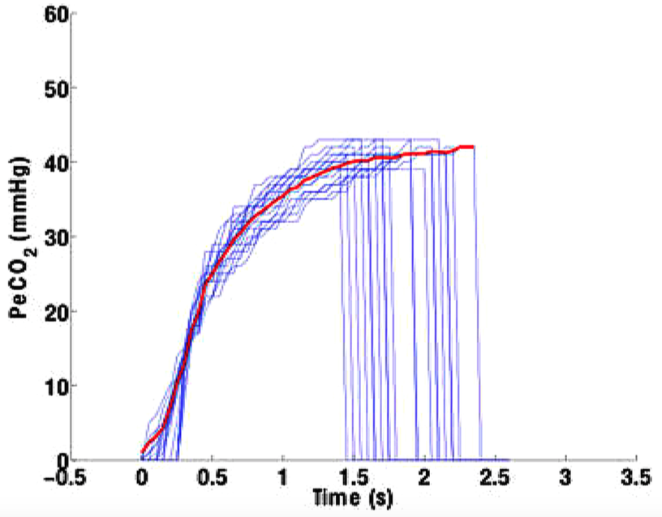

Profil expiratoire d’un capnogramme de patient BPCO. Les exhalaisons de capnogrammes (en bleu) sont alignées à 15 mmHg de PeCO2 puis moyennées verticalement pour construire le profil moyen du capnogramme (en rouge).

Les expirations atypiques ont été reconnues et exclues en utilisant le profil moyen comme référence de capnogrammele modèle de capnogramme comme exemple de respiration. Chaque expiration a été notée sur la base d’une mesure globale des déviations par rapport au profil moyen standard, en se référant à l’écart-type approprié (associé). Les expirations, dont l’écart global dépassaient un certain seuil, étaient exclues de l’analyse et de la classiffication. Après le prétraitement automatisé de chaque enregistrement pour éliminer les exhalaisons des valeurs aberrantes, les 80 premières expirations valides de chaque enregistrement ont été utilisées pour l’analyse.

Les quatre caractéristiques physiologiques utilisées pour la conception de l’électeur ont été sélectionnées à l’aide de l’analyse de validation croisée décrite plus loin et comprenaient les éléments suivants *figure 4*:

- durée de l’expiration;
- PeCO2 maximum ou PeCO2 de fin d’expiration (ETCO2);
- temps passé à ETCO2;
- pente de fin d’expiration.

La durée d’expiration est la durée entre le début de l’expiration et la fin de celle-ci. PeCO2 maximum est la valeur PeCO2 à la fin de l’expiration. Le temps passé à ETCO2 est la durée pendant laquelle PeCO2 reste à sa valeur maximale. La pente d’expiration finale a été calculée comme la pente d’une droite correspondant aux cinq dernières valeurs de PeCO2 de l’exhalation.

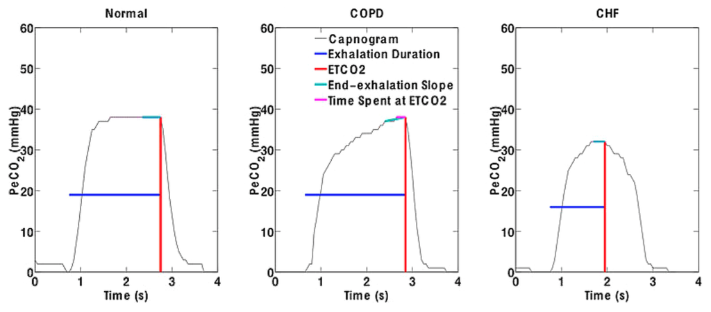

Quatre caractéristiques extraites du capnogramme et utilisées pour la classification. Celles-ci comprennent : la durée de l’expiration, le CO2 en fin d’expiration (ETCO2), la pente de l’expiration finale et le temps passé à l’ETCO2.

L’entraînement et le vote de chaque électeur se déroulent dans l’espace à quatre dimensions défini par les caractéristiques. Deux approches pour la constitution et le vote de chaque électeur ont été suivi. Dans une première approche, respiration par respiration, les caractéristiques de chaque expiration dans l’ensemble des respirations constituent un point de l’espace $\mathbb R^{4}$ des caractéristiques, de sorte qu’il y a autant de points que d’expiration. Dans la seconde approche par moyenne des caractéristiques, les valeurs de ces caractéristiques respectives sont moyennées sur l’ensemble des expirations pour un enregistrement donné permet de définir un point unique dans l’espace $\mathbb R^{4}$ des caractéristiques.

Dans cette article les auteurs fond par des besoins informatiques, du coût qu’on nécessité les calculs de ces analyses. Les calculs pour le prétraitement, l’extraction de caractéristiques, la validation croisée et la construction ROC sur l’ensemble de l’ensemble ont duré moins de 2,7 minutes sur un ordinateur portable MacBook Pro 2012 (Apple, Cupertino, Californie) avec 4 Go de RAM et un processeur Intel Core i7 de 2,2 GHz. processeur exécutant MATLAB 2013a (MathWorks, Natick, Massachusetts).

Un seuil de 60%, correspondant à une sensibilité et à une spécificité d’environ 0,78, a été choisi pour la classification entre ICA et BPCO. Ce seuil correspond au seuil minimal de votant en faveur d’une ICA pour le calsser comme tel par rapport à une exacerbationd de BPCO. De la même manière un seuil de 50% de votant en faveur d’une exacerbation de BPCO pour le classifier comme tel par rapport à des patients normaux indemnes de pathologie pulmonaire. Ce seuil correspond à une sensibilité et une spécificité d’environ 0.88.

L’exécution des classificateurs en utilisant l’approche respiration par respiration avec 80 expirations retrouve des performance diagnostique pour la classificaiton des patients ICA et BPCO avec une AUC de 0,89 (IC à 95%: 0,72-0,96). La courbe ROC pour la classification entre patient BPCO et normaux retrouvait une AUC de 0,98 (IC à 95%: 0,82-1,0). L’approche respiration par respiration présentait de meilleurs performance diagnostique avec une AUC supérieure sur l’ensembles de test diagnostique aussi bien pour les ICA/BPCO que pour les BPCO/Normaux, par rapport à l’approche moyennant les caractéristiques.

### Model-Based Estimation of Pulmonary Compliance and Resistance Parameters from Time-Based Capnography [10]

- $C_{l}$ : la compliance pulmonaire
- $R_{l}$ : la résistance des voies aériennes
- $\Delta P$ : gradient de pression moteur en expiration
- $p_{A}$ : pression partielle de CO2 alvéolaire
- $V_{D}$ : volume de l’espace mort anatomique

Tableau 1: Paramètres

| paramétres | description |
| --- | --- |
| $C_{l}$ | la compliance pulmonaire |
| $R_{l}$ | la résistance des voies aériennes |
| $\Delta P$ | gradient de pression moteur en expiration |
| $p_{A}$ | pression partielle de CO2 alvéolaire |
| $V_{D}$ | volume de l’espace mort anatomique |

### Model-Based Estimation of Respiratory Parameters from Capnography, with Application to Diagnosing Obstructive Lung Disease [11]

Ce nouvelle article de *Abid A. et al.* s’inscrit dans les suites du précédent publié en 2015 [10] se basant sur un modèle mathématique de type mécanistique pour analyser la courbe. Ce travail comporte deux phases d’analyse. La première phase a pour objectif d’estimer les paramètres respiratoires $\tau$ et $\alpha$, décrivant la courbe de capnographie résultant de l’équation se basant sur le modèle mécanistique. La seconde phase évalue le modèle sur les différentes phases d’un test à la métacholine chez des patients asthmatiques.

Les enregsitrements de capnographie ont été réalisés en service d’EFR en position assise portant à l’aide d’une canule nasale reliée à un capnographe portable *(Capnostream 20, Covidien, Mansfield, Massachusetts)*. La durée des enregistrements étaient de longueur variable entre 2 et 20 minutes avec un fréquence d’échanillonnage de 20Hz avec une résolution d’amplitude de 1mmHg. Ce protocol a été suivi pour l’ensemble des enregistrements concernant les deux phases de l’étude.

Première partie : L’objectif de cette première partie de l’étude était de détreminer (d’évaluer) la possibilité de distinguer de manière fiable, à l’aide des paramètres $\tau$ et de $\alpha$, les sujets normaux des patients atteints d’une BPCO. *ou* L’objectif de cette première partie de l’étude était de détreminer si les différences des paramètres $\tau$ et de $\alpha$ entre les deux populations permettaient de distinguer de manière fiable les sujets normaux des patient atteints d’une BPCO. La population étudié était composée de 46 sujets dont 22 présentaient une BPCO et 24 considéré comme normaux. Après le prétraitement des données, 71% des expirations normales et 51% des expirations de patients BPCO ont été retenues, permettant l’extraction(l’estimation) des paramètres $\tau$ et de $\alpha$ pour chaque expirations valides. Les moyennes de $\tau$ et de $\alpha$ pour les deux populations de sujets normaux et BPCO ont été calculées. Ces dernières étaient en accord avec les valeurs retrouvées dans la littérature aussi bien pour les sujets normaux que BPCO. Aucune analyse statistiques sur la comparaisons des moyennes des deux paramètres entre les populations n’apparaient dans l’article. A ce stade, les auteurs considèrent que les différences retrouvées suggèrent qu’il est possible de concevoir un classifieur permettant de distinguer les deux populations. Un groupe d’apprentissage a été constitué en selectionnant aléatoirement 5 sujets normaux et 5 patients BPCO permettant d’analyser 1346 expirations valides et d’en extraire les paramètres $\tau$ et de $\alpha$. Compte tenu que la distribution des paramètres présentaient une distribution proche d’une loi log-normale, une analyse discriminante linéaire [ref. 24] a été réalisée dans le plan $\ln(\tau)-\ln(\alpha)$. Cette dernière a permis d’établir un classifieur linaire représenté par une droite permettant de séparer les deux populations. La fonction *fitcdiscr* de *MATLAB* a été employée à cette effet (dans ce but). Le classifieur résultant a obtenu une précision de 89,5% sur les 1346 expirations de l’ensemble d’apprentissage. Par la suite le classifieur a été testé sur les 36 sujets restants, classant chaque expirations comme normale ou BPCO. Par la suite pour chaque sujet a été établi la proportions d’expirations classifés comme normale et comme BPCO. Cette proportion comparer à un seuil a permis d’étiquetter (de ranger/ d’assigner/ de considérer/ de classer) les patients dans l’un des deux groupes. Une courbe ROC, pour estimer les pefromances du classifieurs, a été établi en faisant varier la valeur du seuil. Les perfomances retrouvées étaient très bonne avec une aire sous la courbe (AUC) de 0.99 (IC95% 0.96-1.00) avec des taux de vrais positifs très élevés tout en maintenant des taux de faux positifs inférieur à 20%.

Seconde partie : L’objectif de la seconde partie de cette étude était d’appliqué le modèle à une maladie obstructive réversible. Pour cela, 22 patients présentants un asthme avec un test à la Métacholine positif ont été recruté. Ce dernier était considéré comme positif lorsqu’il induisait un bronchospasme mesuré par une chute inférieure à 80% de la valeur de référence du volume expiratoire maximal par seconde (VEMS) en spirométrie. Dans ce test la métacholine, irritant pulmonaire, était administrée par inhalation à dose croissante. Tous les sujets ont été traité par de l’albuterol, un bronchodilatateur, à la fin du test à la métacholine pour mettre en évidence la réversibilité du bronchospame. Un enregistrement a été ralisé durant chacun des trois stades de l’examen : avant et après l’administration de métacholine, puis après administration d’un bronchodilatateur. Dans cette partie la valeur de la $p_{A}$ a été définit pour chaque patient comme la valeur maximale d’EtCO2 mesurée au décours des trois stades. Ainsi, la valeur de la $p_{A}$ variait d’un patients à l’autre mais pas chez un même patient. Les paramètres $\tau$ et $\alpha$ de chaque expiration, de chaque stade et de chaque patient ont été extrait comme vu précédement. Les médianes de $\tau$ et de $\alpha$ ont été calculées, observées et comparées au cours des trois étapes. On observe que la valeur médiane de $\alpha$ après administration de métacholine est plus basse comparativement au stade avant métacholine ou après albutérol. A l’inverse, pour $\tau$, la médiane augmente. Pour observer si ces tendances se généralisaient à tous les patients, les proportions des différences (des variations) entre deux médianes ($\Delta\tau/\tau_{0}$ et $\Delta\alpha/\alpha_{0}$) entre deux stades de l’examen à la métacholine ( *avant/après métacholine* et *après métacholine/après albutérol* ) ont été calculées. Ces variations entre les médianes, représentés par des vecteurs en 2D dans le plan $\tau-\alpha$, ont été agrégés sur l’ensemble des 22 patients et représentés sur la figure 11(7).

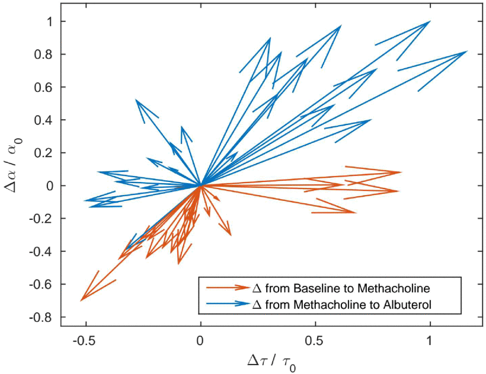

Proportions des variation entre les stades des valeurs médianes des 22 patients représentés sous forme de vecteur.

$$p_{D}(t)=p_{A} (1-\mathrm{e}^{-\alpha} \mathrm{e}^{\alpha\mathrm{e}^{-\frac{t}{\tau}}})
\tag{2}$$

Le paramètre $\tau=R_{l}C_{l}$ représente la constante de temps pulmonaire. Le parmètre $\alpha$ définit par $\alpha= \frac{C_{l}\Delta P}{V_{d}} =\frac{V_{T}}{V_{D}}$ où la quantité $C_{l}\Delta P=V_{T}$ représente le volume courant (en supposant une compliance pulmonaire linéaire), donc $\alpha$ est approximativement l’inverse de la fraction de l’espace mort pulmonaire

### Bayesian Tracking of a Nonlinear Model of the Capnogram [46]

En 2006, Buijs et al. ont présenté une méthode Bayésienne pour l’identification de capnogramme volumétrique respiration après respiration (35). La méthode intègre un modèle d’échange de CO2 dans les poumons, en raison de la nature non-linéaire de la respiration humain. Ce modèle représente le flux respiratoire et intègre un compartiment de réinhalation, un compartiment espace mort des voies aériennes et un compartiment représentant les alvéoles. En utilisant ce modèle une prédiction pour la tension de CO2 alvéolaire non mesurée pourrait être faite. Basé sur des modèles de simulations, il est montré que l’algorithme adaptatif est capable de suivre rapidement les fluctuations de mesures du CO2. La structure du modèle présentée cette recherche est basée sur la connaissance physiologique a priori, où les paramètres du modèle ont des significations physiques claires. Ceci a l’avantage que le modèle peut être utilisé pour aider dans l’interprétation du capnogramme. Cependant, si la méthode actuelle veut aider le clinicien dans l’interprétation des données de capnographie, il est nécessaire de fournir en directe des paramètres physiologiquement pertinents qui seront déterminant pour l’analyse. Montre la simulation d’un capnogramme, utilisant des paramètres modèles par défaut. Cependant, des modèles physiques précis contiennent souvent des non-linéarités, comme des variabilités dans le temps du flux d’air et de volume alvéolaire, aussi bien que l’alternance entre l’inspiration et l’expiration dans le modèle respiration de flux. À cause de ces non-linéarités, l’identification des paramètres du modèle exige un certain type d’algorithme d’optimisation(36). Ces algorithmes sont souvent hors connexion (en mode autonome) et exigent la supposition que les paramètres du modèle soient constants au cours de la période d’analyse. De plus, la division en compartiments simples de l’espace mort des voies aériennes et du volume alvéolaire semble être une schématisation grossier, compte tenu que les voies aériennes humaines sont constitués de nombreuses bronches et de millions d’alvéoles, avec probablement des propriétés différentes en termes d’échange gazeux. En outre, le taux métabolique de CO2 est un paramètre condensé ou composite, qui reflète les modifications du flux sanguin par exemple pulmonaire, la production de CO2 des tissus et l’hétérogénéité des rapports ventilation perfusion alvéolaires. Le modèle ne permet pas de distinguer l’importance de l’influence de ces différents phénomènes physiologiques. Il est donc nécessaire, pour envisager une utilisation clinique future, de réaliser de plus amples études sur des données tant simulées qu’expérimentales qui permettront mieux définir avantage et les limites de ce méthode.

### Online-Classification of Capnographic Curves Using Artificial Neural Networks [61]

Le but de l’algorithme de classification par corrélation est d’isoler les capnogrammes analysables des échantillons de bruit. Un algorithme de seuil simple sélectionne des capnogrammes individuels à partir de la courbe de CO2 et les normalise à une longueur uniforme de 25 points de données. Ensuite, les similitudes des capnogrammes sont testées en les corrélant les unes avec les autres. Deux capnogrammes sont considérés comme suffisamment similaires avec un coefficient de corrélation supérieur à 0,9. Des capnogrammes similaires sont stockés dans une catégorie, appelée cluster. Chaque grappe est représentée par un capnogramme modèle, résultant de la moyenne de tous les capnogrammes de cette catégorie. Même si le nombre de grappes peut en principe varier, ces travaux limitent le nombre de grappes à cinq. Il y a toujours un cluster “Corbeille”, qui contient tous les capnogrammes qui n’ont pas ou très peu de ressemblance avec un autre cluster. Après un premier traitement, les modèles sont inspectés visuellement. Les valeurs aberrantes évidentes dans tout groupe, comme les courbes sans structure, sont immédiatement affectées au groupe “Corbeille”. Au cours de l’exécution de l’algorithme de cluster, les modèles ont tendance à changer constamment car ils ne représentent qu’une moyenne. Pour maintenir leur similarité avec le cluster, ils sont également vérifiés. En cas de forte similarité de deux modèles, les clusters d’origine sont fusionnés. Les capnogrammes du groupe “Corbeil” sont régulièrement réévalués avec les modèles existants et, si nécessaire, re-classés.

### A scoring system for capnogram biofeedback: preliminary findings [62]

### Recognition of cardiogenic artifact in pediatric capnograms [63]

Une des principale problématique en anesthésie pour la surveillance ventilatoire en utilisant la capnographie est l’apparition d’artefact. Ces derniers sont généralement dû à des oscillations cardiogénqiues entraiant un défaut de reconnaissance de l’EtCO2 mais également de la fréquence respiratoire. Un capnographie de type *Engström Eliza capnographe* a été utilisé pour réaliser les enregistrement par voie nasale sur des sujets présentant un syndrome obstructif. Le but de l’étude était d’évaluer un algorithme de reconnaissance et de correction des artéfacts par oscillations cardiogéniques, et de le comparer à un autre système de détrection des artéfacts : CAPNOG. Les artéfacts par oscillations cardiogérniques sont facillement reconnaissable à partir de capnogramme seul. Il présentent les caractéristiques suivantes : ils ont toujours une forme lisse, avec une montée et une descente rapide, sans aucun plateau inspiratoire ni expiratoire. Le pic de chaque oscillation est inférieur au pic précédent, bien que la première puisse parfois être légèrement supérieure à la valeur d’EtCO2 de la respiration dont elle est issue. Le minimum de la première oscillation est toujours supérieur au minimum de la vraie phase inspiratoire précédente. Avec les oscillations suivantes, ce minimum diminue généralement jusqu’à atteindre les niveaux de gaz inspiré. La caractéristique la plus spécifique des oscillations cardiogéniques est leur courte durée, avec une fréquence égale à la fréquence cardiaque sous-jacente. L’algorithme développé repose sur l’association de chaque expiration associée à l’inspiration suivante en un cycle. L’algorithme analyse le tracé de capnographie cycle par cycle en utilisant comme paramètres l’EtCO2, les temps inspiratoire (Tb) et expiratoire (Ta) ,et le taux de CO2 minimal lors de la phase inspiratoire (Minco2). L’algorithme compare les respirations entre elle en réalisant un système de classement et de validation en cycles normaux et en cycles présentant des artéfacts en rapport avec des oscillations cardiogréniques. Lorsque l’agorithme reconnait un clycle comme un artéfact d’oscillation cardiogénique, ce dernier est intégré au dernier cycle valide en intégrant son temps et en lui appliquant l’EtCO2 du cylce précédent. Ce cycle respiratoire reconstitué sera considéré comme le dernier cycle valide. Pour qu’un cycle soit identifier comme une oscillation cardiogénique, il doit satisfaire les l’ensemble des critères que resprésente les conditions 1 à 4. Cette reconnaissance (analyse) se fait en deux étapes. Une première applique les conditions 1 et 2 à l’ensemble des cycles. Secondairement, les condition 3 et 4 ne sont appliqués que si le dernier souffle lu a été évalué comme étant un véritable souffle.

- Condition 1 : Last-valid-breath.Tb + Current-breath.Ta $\leqslant 1.2 sec$
- Condition 2 : Current-breath.EtCO22 $\leqslant$ Last-valid-breath.EtCO2 + 0.15%CO2
- Condition 3 : Current-breath.Ta < Last-valid_breath.Ta
- Condition 4 : Current-breath.Minco2 + 0.15%CO2 > Last-valid_breath.Minco2

### Calculating the Effect of Altered Respiratory Parameters on Capnographic Indices [12]

Le but de cet article était d’établir la relation quantitative entre les paramètres physiques du système respiratoire et les indices de forme du capnogramme. Pour atteindre cet objectif, un modèle mathématique non linéaire de l’échange de CO2 dans les poumons a été simulé dans diverses conditions. Ce modèle prenait en compte la respiration avec l’évolution du CO2 en fonction du temps. Il est modélisé par 3 compartiements : un compartiment de réinspiration, un compartiment d’espace mort des voies respiratoires et un compartiment représentant les alvéoles. Par la suite, les indices de forme ont été calculés à partir des simulations au capnogramme. Les présents résultats pourraient constituer une ligne directrice pour les cliniciens dans l’interprétation physiologique du capnogramme.

- phase II (indice 1) : supérieur à T1 et compris entre EtCO2 10 et 50% (0.1 et 0.5)
- phase III (indice 2) : supérieur à T1 et correspondant à l’interval ou la dérivée seconde est inférieur à 15 mmHg/sec2
- phase 0 (indice 3 : inférieur à T1 et correspondant à la portion entre EtCO2 75 et 25% (0.75 et 0.25)

Le modéle suivant a été utilisé pour simuler le débit d’air avec l’évolution du CO2 au cour du temps :
$$\dot{V} = \left\{ \begin{array}{rcl}
V_{T}/T_{1} & t\leqslant T_{1}
\\ -\gamma V_{T}\mathrm{e}^{-\gamma(t-T_{1})} & T_{1}<t\leqslant T
\end{array}\right.$$

Les modifications de la distribution ventilation-perfusion V/Q influencent radicalement la forme du capnogramme [5]. Dans les poumons normaux, une seule constante de temps suffit pour se rapprocher de la vidange alvéolaire. Cependant, chez les patients atteints de maladie pulmonaire obstructive, plusieurs constantes (taux) de vidange sont nécessaires pour décrire l’expiration [12]. Cette modélisation est nécessaire pour exprimer l’hétérogénéité de vidange du compartiement alvéolaire des patients obstructif. Pour simuler l’hétérogénéité V/Q, la phase expiratoire a été divisée en deux phases: une phase courte de TI jusqu’à TE,1 avec une constante de vidage rapide $\gamma1$; par la suite, une phase plus longue de vidange lente des voies respiratoires obstruées avec une constante $\gamma2$. L’équation de débit d’air de la phase expiratoire a été adaptée de la manière suivante:

$$\dot{V} = \left\{ \begin{array}{rcl}
-\gamma_{1}V_{T}\mathrm{e}^{-\gamma_{1}(t-T_{I})} & T_{I}<t\leqslant T_{E,1}
\\ -\gamma_{2}V_{T_{E,1}}\mathrm{e}^{-\gamma_{2}(t-T_{E,1})} & T_{E,1}<t\leqslant T
\end{array}\right.$$

### Enhancing ventilation detection during cardiopulmonary resuscitation by filtering chest compression artifact from the capnography waveform [65]

## Discussion

### Population et Pathologie étudiées

Patient normaux, obstructif, restrictif, fibrose. Problèmatique est avoir des élements de mesures qui nous permets d’analyser et d’évaluer plus finement le fonctionnement pulmonaire, à but diagnostique (pathologie ou différencation entre pathologie BPCO et Insuffisance Cardiaque par exemple), à but pronostique (évolution de la maladie dans le temps, aggravation ou amélioration, comme surveillance, après traitement), pour mieux adapter le traitement (problématique de ventilation ou de perfusion, adapter le traitement en fonction du malade et de sa pathologie). Les informations ou mesures permettants d’évaluer la fonction pulmonaire : - FR (fréquence respiratoire) - VT (volume courant) - Q (débit expiratoire) - SpO2 (% des globules rouges oxygénés) - PaO2 (pression partielle artérielle en O2) - VO2 (volume d’O2 consommé) - PaCO2 (pression partielle artéreille en CO2) - EtCO2 (pression de CO2 en fin d’expiration) - VCO2 (volume de CO2 expiré) - V/Q (rapport ventilation perfusion) - VD (espace mort : anatomique et physiologique sont important) Les grands fonction du poumons : - la ventilation (volume, fréquence, hétérogénéité de ventilation, dépendant des résistances et de la compliance pulmonaire) - la perfusion (débit/volume, hétérogénéité de perfusion) - la diffusion des gazs (surface d’échange, résistances à la diffusion)

### Prétraitement

- problèmatique d’analyse de la courbe. Deux modes principaux :
- Un mode d’analyse (éparce) en découpant la courbe capnogramme par capnogramme.
  - Avec secondairement une analyse de chaque capnogramme pour un enregistrement pour avoir des mesures des caractéristiques de la courbe capnogrammme par capnogramme permettant d’en estimé une moyenne, une médiane et une déviation standard (ou un écart type). Problème de selection des capnogrammes correctes et abérrants. Mesure de la variablité : méthode et intérêt.
  - OU analyse après production d’un profil moyen en moyennant les courbes après supperposition centrées sur une valeur, un maqueur, un criètre des différents capnogramme facielement identifiable : une valeur fixé (15 mmHg comme chez Mieloszik [60]) ou la valeur maximale de la pente identifiable par le pic positif (valeur max) de la dérivée première.
- Un mode d’analyse globale en prenant un compte un ensemble définit de la courbe avec plusieurs capnogramme analysé. Utilisé dans l’analyse par transformée de Fourier mais pourrait s’appliquer à l’analyse par transformée en ondelettes.

[12] : méthode de segmentation du capnogramme pour les différentes phases à étudier.

### Features ou caractèristiques analysées

### Méthode de d’analyse de la courbe

- mesure simple de paramètres (temps, EtCO2, pente, surface sous la courbe)
- Ajustement par rappor à une équation (modéle mécanistique) * équation associé à un modèle mécanistique proche de la physiologie ou * équation décrivant le plus fidélement la courbe avec une meilleur adaptabilité au differente forme et déformation de la courbe (intérêt pour distinguer des pathologies BPCO/Emphysème/Asthme)
- trasnfromée de Fourier (avec également la PSD : power spectral density)
- transformée en ondelette
- Bayesian model
- nouveaux paramètres de Hjorth

### Méthode de Classification

- régression logistic
- régression linéaire simple
- ACP (analyse en composantes principales)
- LPC analysis (linear predictive coding)
- AR modeling (autoregressive modeling)
- PSD (power spectral density)
- GRBF network (gaussian radial basis function network)
- l’Analyse Linéaire Discriminante (égale à la LPC)
- SVM (séparateurs à vaste marge ou machine à vecteurs supports)
- LDA (analyse linéaire discriminante)

### Proposition d’approche

- voir si l’âge à une influence sur la courbe de capnographie chez des patients normaux.
- l’incidence de la variablité de la courbe de capnographie, des capnogrammes au cours du temps. Effet perturbateur mais également intêret pour l’analyse et la classification. Variation plus importante ou moins importante des capnogrammes en fonction des pathologies ? (variabilité intra-classe ou intra-patient, variabilité inter-class ou inter-patient)
- Analyse et comparaison de différent modèle mécanistique, différente équation de courbe.
- Rercher de capnogramme typique en fonction des pathologies, l’associé à des ondelettes mères dans une transformée en ondelettes.
- Approche “multi-échelle” ou “multi-filtre” : en utilisant des analyses différentes de la courbes pour en extraire des paramètres ou caractères différents pour identifier les différentes pathologies comme l’Insuffisance Cardiaque, les syndromes obstructifs dans leur divers aspect, les pathologies restrictives, les fibroses et les HTAP. Un peu comme du Deep Learning avec l’application de masque comme des réseaux convolutifs pour exprimer de façon les différentes pathologies. Par exemple, par une transformer de fourier, une transformer en ondelettes (en y associant l’inspiration), une approche mécanistique avec un ajustement de la courbe à un modèle, mesure de paramètres simple comme l’aire sous la courbe, etc…
- évaluation statistique comme le “Compress Sensing” : reconnaitre les maladies en fonction des capnogramme (+/- capnographie volumétrique et différence PaCO2-EtCO2)
- évaluation des meilleurs critères(ou caractéristiques), des meilleurs association de critères(ou caractéristiques) comme des rapport de pentes SR=S2/S1x100
- évaluation d’une opération mathématique sur les critères(ou caractéristiques) comme un “Log” pour mieux dispercé (étalé pour mieux séparer) l’information. Voir comment se comporte les paramètres (il est plus difficile de séparer les patients normaux des sub-pathologiques)
- évaluation en appliquant un filtre ou non, entre filtre, ceux qui donnent les meilleurs pefromances diagnostiques.
- combinaison de plusieurs paramètres d’analyse, de plusieurs type d’analyse (parametre, modele mécanistique, décomposition fréquencielle)
- évaluation des paramètres ou algorithme pour reconnaitre et séparer les cycles respiratoires, les phases inspiratoires et expiratoire, les phases de la courbes, en vu de l’analyse.
- gestion des artéfacts, filtrage ou élimination des artéfacts ou des capnogrammes artéfactés.
- quel classifieur utiliser pour classer les patients.
- évaluation de la sévérité du trouble obstructif, corrélation de paramètres avec le VEMS ou autres mesures spirométriques
- analyse de la partie descendante de la courbe : l’inspiration qui peut-être informatif et associé à la compliance (comme dans les syndrome restrictif)

### Hypothèse physiopathologique et capnographie

Les débits réduits dans le syndrome obstructif prolongent la phase transitionnelle entre l’espace mort anatomique et les gaz alvéolaire car le volume de l’espace mort prend plus de temps à s’exhaler, ce qui fait que la pente et l’angle de décollage diminuent en proportion directe de la gravité de l’obstruction. Normalement l’évacuation des gaz alvéolaires s’effectue de façon homogène avec une évacuation synchrone des alvéoles qui présente une discrète hétérogénéité de concentration en CO2. On peut considérer que l’ensemble des alvéoles présente une concentration relativement homogène. Ce qui entraine une absence de pente voir une pente minime lors de l’évacuation des gaz alvéolaire sur le capnogramme. Dans l’OD, certaines bronches terminales sont rétrécies, entraînant une hypoventilation locale des alvéoles et une augmentation associée de leur concentration en CO2. Les alvéoles attachés à des bronches terminales non obstruées sont relativement hyperventilés et ont des concentrations réduites de CO2. Pendant l’expiration, les alvéoles non obstruées se vident devant les alvéoles obstruées, conduisant à une augmentation progressive de la concentration en CO2 pendant l’expiration. Cette vidange inégale des alvéoles donne au plateau alvéolaire une apparence caractéristique en pente dans la DO.

Dans l’asthme, l’obstruction des voies respiratoires provoque des diminutions régionales du débit d’air et, par conséquent, de la ventilation alvéolaire. Ceci est responsable de “l’hétérogénéité parallèle” des rapports ventilation-perfusion (rapports V / Q). Sur le capnogramme, cela provoque une déformation de la courbe normale, marquée par la perte de verticalité de la phase 2, l’ouverture de l’angle entre les phases 2 et 3 (angle alpha également appelé angle Q) et l’augmentation de l’inclinaison de la phase 3.

[66][10] La forme du capnogramme pourrait ne pas être uniquement lié à des modifications de résistance mais également à la modification de la compliance pulmonaire.

L’analyse automatisé de multiples indices capnographiques peut augmenter la sensibilité et la spécificité du diagnostic des maladies pulmonaires obstructives. Une combinaison de durée d’expiration, ET-CO2, pente expiratoire et temps passé à ET-CO2 permet de distinguer les patients atteints de BPCO de ceux souffrant d’insuffisance cardiaque congestive [44]. La capnographie peut être encore plus sensible que la spirométrie pour détecter les petites voies aériennes précoces changements, comme cela a été démontré pour la technique similaire du lavage à l’azote à un seul souffle [45,46].

[68] Montre dans son article que l’EtCO2 et la PaCO2 sont fortement corrélée pour des valeur de ration VD/VT < 0.4 donc faible, avec un gradient en moyenne de l’ordre de 0.3 mmHg. Par contre plus le rapport entre espace mort physiologique sur volume courant augmente plus la corrélation baisse et le gradient augmente jusqu’à 18 mmHg en moyenne pour un rapport VD/VT > 0.7. Cela va dans le sens d’une augmentation de l’espace mort physiologique lorsque le gardient entre EtCO2 et PaCO2 augmente. Ce qui pourrait s’expliquer par une augmentation de l’hétérogénéité du rapport ventilation-pefrusion V/Q. [69] Lujan retouve les mêmes résultats avec des gradients entre PaCO2 et EtCO2 augmentés ches les patients présentant un trouble obstuctif en spirométrie d’intensité différente. Pour les patients ne présentant pas d’anomaie spirométrique le gradient moyen étais de 1.7 +/- 2.9 mmHg et pour les patients présentant un syndrome obstructif important les gradient était de 8.2 +/- 5.6 mmHg. [12] : la simulation de la distribution inhomogène de R V / Q a entraîné une augmentation de l’angle A comparable aux observations chez les patients présentant des voies respiratoires obstruées [2, 5].

[70] le CO2 présente des caractéristiques particulières telles que sa grande solubilité, son transfert inverse de l’O2 du sang à l’alvéole et son mécanisme de transport complexe dans le sang. À cet égard, le SBT-CO2 dépend davantage des changements dans les relations ventilation-perfusion, ce qui rend presque impossible la différenciation des effets de la ventilation sur ceux de la perfusion sur la forme de SIII. En capnographie volumétrique, les résultats de cette étude montrent que SII et SIII ont changé à mesure que le débit sanguin pulmonaire augmentait progressivement au cours de la phase de sevrage du de la circulation extra-corporelle. Cependant, lorsque SII et SIII ont été normalisés en les divisant par le CO2 alvéolaire expiré moyen, ces pentes sont restées inchangées. La normalisation des pentes de cette manière annule l’effet de l’amplitude du débit de perfusion pulmonaire sur le SBT-CO2. Ainsi, tout changement dans SnII et SnIII peut être interprété comme étant causé par des altérations de la distribution de la ventilation et de la perfusion, quelle que soit l’amplitude du débit sanguin pulonaire. Les patients asthmatiques et emphysémateux (18, 25, 30) présentent une diminution du SII par rapport aux sujets normaux. Chez les patients ventilés mécaniquement avec une atélectasie induite par l’anesthésie, nous avons montré qu’après une manœuvre de recrutement pulmonaire dans laquelle le poumon est ré-expansé, le SII augmente (27). Le fait que le recrutement du poumon augmente SII indique que la réouverture de petites voies aériennes évidées entraîne une répartition plus homogène de la ventilation. Par conséquent, une distribution inhomogène de la ventilation semble influencer SII. Malgré l’influence connue de la distribution de la ventilation sur SII, nos résultats ont montré que le PBF a un effet supplémentaire sur cette pente. SII a montré ses valeurs les plus élevées avant et après CPB. Les valeurs les plus faibles ont été trouvées lors du débit de pompage le plus élevé (PBF le plus faible), en observant une augmentation progressive à mesure que le PBF augmentait. Nos résultats concernant le comportement de VTCO2, concordent avec ceux observés dans la simulation théorique réalisée par Schwardt et al. (24). Ces auteurs ont démontré que le débit cardiaque et la tension veineuse de CO2 avaient une relation directe avec VTCO2, les valeurs br, car la concentration alvéolaire moyenne en CO2 dépend principalement de la vitesse à laquelle les molécules de CO2 sont délivrées par le circulation pulmonaire. Les SII et SIII non normalisés étaient affectés par les différents degrés de FBP, alors que les pentes normalisées ne l’étaient pas. Les pentes normalisées décrivent les inhomogénéités de ventilation et de perfusion chez les patients sous ventilation mécanique, indépendamment des modifications de l’ampleur du débit sanguin pulmonaire. Le rôle de la normalisation des pentes sur la distribution des débit sanguin pulmonaire reste à déterminer.

### Divers

- Critères de qualités de l’analyse de la courbe
- Variabilités des courbes : paramètres, intra-class, intra-patient…

La pente de la phase III du capnogramme (SIII) concerne (est le reflet de) la vidange progressive des alvéoles, un décalage de ventilation/perfusion et une inhomogénéité de la ventilation. SIII dépend non seulement de la géométrie des voies aériennes, mais également de la compliance respiratoire dynamique (Crs).

Intérêt du CO2 est qu’il ne necessite pas un apport externe comme un médicament que l’on injecterait. Il est présent constitutionnellement dans le corps et surtout n’est pas dépendant de l’inspiration. Il est présent avec une proportion négligeable dans l’air atmosphérique contrairement à l’Azote N2 avec lequel est réalisé des tests respiratoire pour mesurer l’hétérogénéité de ventilation. Une contrainte avec le CO2 est que son taux artériel varie en fonction de son évacuation par le poumon mais également en fonction de sa production.

Analyser ces signaux EEG se décompose en trois étapes successives qui sont le prétraitement, l’extraction de caractéristiques et la classification. - prétraitement - extraction de caractéristiques - classification L’extraction de caractéristiques consiste à décrire les signaux EEG par un ensemble essentiel (idéallement petit) de valeurs décrivant l’information pertinente qu’ils contiennent, en vue de les classifier.

# Conclusion

modification/apparence “Aileron de Requin” ou “Shark Fin”

La forme d’onde capnographique montre des changements dans le bronchospasme qui reflètent l’hétérogénéité de l’air expiré. Ceci est vu comme une diminution de la pente de la phase 2 et une augmentation de la pente de la phase 3 et l’augmentation résultante de l’angle alpha (angle $\alpha$).

# Annexes

# Mots clés

capnography waveforms

capnogram waveform

capnogram signal

# Divers

[71] [72] [73] [74] [75] [76]

[77] [78] [79] [80]

[19] [47] [50] [49] [44] [60] [58] [59] [54] [30] [48] [51] [52]

Site GLI *(Global Lung Function Initiative)* :

```
          http://gligastransfer.org.au/calcs/tlco.html
```

# Tableaux

## Tableau 1 : Synthèse des études sur la Capnographie Standard

Synthèse des études sur la Capnographie Standard

[output not shown]

# Tableau 2 : Synthèse des études sur la Capnographie Standard

Synthèse des études sur la Capnographie Standard

[output not shown]

# Tableau 3 : Synthèse des études sur la Capnographie Standard

Synthèse des études sur la Capnographie Standard

| Auteur | Année | Effectif | Gold standard | Caractéristiques | Ref. |
| --- | --- | --- | --- | --- | --- |
| babik | 2012 | 68 | Res. & Comp. | Pente III | [66] |
| blanch | 1994 | 41 | Résistance | Pente III | [81] |
| brown | 2013 | 20 | Spiro. & TDM | Pente III | [82] |
| egleston | 1997 | 38 | Clinique | Pente S1, S2 & SR | [48] |
| evered | 2003 | 12 | Spiro. & Res. | Pente III & angle alpha | [83] |
| hisamuddin | 2009 | 100 | DEP | Pente II, III & angle alpha | [44] |
| howe | 2011 | 30 | DEP | Pente II, III & angle alpha | [30] |
| ioan | 2014 | 8 | Res. & Comp. | Pente II, III, angle alpha, D1,D2 | [84] |
| kean | 2010 | 34 | Spiro. & clinique | 8 critères de You | [55] |
| kline | 1998 | 139 | Scinti & TDM pulm | Surface sous la courbe | [41] |
| krauss | 2005 | 262 | Spiro. | Pente II, III, EtCO2, FR, Tps Insp & expi. | [49] |
| lopez | 2011 | 21 | Clinique | Pente II, III, EtCO2, Tps Insp & expi., PcCO2-EtCO2 | [85] |
| lukic | 2006 | 5 | Clinique | 18 critères | [86] |
| mieloszyk | 2014 | 139 | Clinique | Pente III, EtCO2, Tps exp., Tps EtCO2 | [60] |
| mieloszyk | 2015 | 56 | Cliniique | EtCO2, pente S1, S2, S3 & SR | [87] |
| yaron | 1996 | 48 | DEP | Pente III | [47] |
| you | 1994 | 40 | Sprio. | S1, S2, S3, SR, AR, SD1, SD2, SD3 | [50] |

# References

[1] W. W. Busse, S. Banks-Schlegel, and S. E. Wenzel, “Pathophysiology of severe asthma,” *Journal of Allergy and Clinical Immunology*, vol. 106, no. 6, pp. 1033–1042, 2000.

[2] I. Tillie-Leblond, C. Iliescu, and A. Deschildre, “Physiopathologie de la réaction inflammatoire dans l’asthme,” *Archives de pediatrie*, vol. 11, pp. S58–S64, 2004.

[3] J. B. West, *Physiopathologie respiratoire*. Pradel, 1988.

[4] L. Plantier, A. Pradel, and C. Delclaux, “Mechanisms of non-specific airway hyperresponsiveness: Methacholine-induced alterations in airway architecture,” *Revue des maladies respiratoires*, vol. 33, no. 8, pp. 735–743, 2016.

[5] J. C. Hogg, “Pathophysiology of airflow limitation in chronic obstructive pulmonary disease,” *The Lancet*, vol. 364, no. 9435, pp. 709–721, 2004.

[6] P. Wagner, D. Dantzker, R. Dueck, J. Clausen, and J. West, “Ventilation-perfusion inequality in chronic obstructive pulmonary disease.” *The Journal of clinical investigation*, vol. 59, no. 2, pp. 203–216, 1977.

[7] J. E. McDonough *et al.*, “Small-airway obstruction and emphysema in chronic obstructive pulmonary disease,” *New England Journal of Medicine*, vol. 365, no. 17, pp. 1567–1575, 2011.

[8] J. C. Hogg, J. E. McDonough, and M. Suzuki, “Small airway obstruction in copd: New insights based on micro-ct imaging and mri imaging,” *Chest*, vol. 143, no. 5, pp. 1436–1443, 2013.

[9] C. F. Vogelmeier *et al.*, “Global strategy for the diagnosis, management, and prevention of chronic obstructive lung disease 2017 report. gold executive summary,” *American journal of respiratory and critical care medicine*, vol. 195, no. 5, pp. 557–582, 2017.

[10] A. Abid, R. J. Mieloszyk, G. C. Verghese, B. S. Krauss, and T. Heldt, “Model-based estimation of pulmonary compliance and resistance parameters from time-based capnography,” in *Engineering in medicine and biology society (embc), 2015 37th annual international conference of the ieee*, 2015, pp. 1687–1690.

[11] A. Abid, R. J. Mieloszyk, G. C. Verghese, B. S. Krauss, and T. Heldt, “Model-based estimation of respiratory parameters from capnography, with application to diagnosing obstructive lung disease,” *IEEE Transactions on Biomedical Engineering*, vol. 64, no. 12, pp. 2957–2967, 2017.

[12] T. K. Roy, J. O. Den Buijs, and L. Warner, “Calculating the effect of altered respiratory parameters on capnographic indices,” in *World congress on medical physics and biomedical engineering 2006*, 2007, pp. 123–126.

[13] P. Wagner, D. Dantzker, V. Iacovoni, W. Tomlin, and J. West, “Ventilation-perfusion inequality in asymptomatic asthma,” *American Review of Respiratory Disease*, vol. 118, no. 3, pp. 511–524, 1978.

[14] E. Ballester, A. Reyes, J. Roca, R. Guitart, P. Wagner, and R. Rodriguez-Roisin, “Ventilation-perfusion mismatching in acute severe asthma: Effects of salbutamol and 100% oxygen.” *Thorax*, vol. 44, no. 4, pp. 258–267, 1989.

[15] P. Wagner, G. Hedenstierna, and R. Rodriguez-Roisin, “Gas exchange, expiratory flow obstruction and the clinical spectrum of asthma,” *European Respiratory Journal*, vol. 9, no. 6, pp. 1278–1282, 1996.

[16] K. Luft, “Über eine neue methode der registrierenden gasanalyse mit hilfe der absorption ultraroter strahlen ohne spektrale zerlegung,” *Z. tech. Phys*, vol. 24, pp. 97–104, 1943.

[17] K. Bhavani-Shankar, H. Moseley, A. Kumar, and Y. Delph, “Capnometry and anaesthesia,” *Canadian Journal of anaesthesia*, vol. 39, no. 6, pp. 617–632, 1992.

[18] R. Aitken and A. Clark-Kennedy, “On the fluctuation in the composition of the alveolar air during the respiratory cycle in muscular exercise,” *The Journal of physiology*, vol. 65, no. 4, pp. 389–411, 1928.

[19] A. B. Chilton and R. W. Stacy, “A mathematical analysis of carbon dioxide respiration in man,” *The bulletin of mathematical biophysics*, vol. 14, no. 1, pp. 1–18, 1952.

[20] W. S. Yamamoto, “Mathematical analysis of the time course of alveolar co2,” *Journal of applied physiology*, vol. 15, no. 2, pp. 215–219, 1960.

[21] M. B. Jaffe, “Infrared measurement of carbon dioxide in the human breath:‘breathe-through’ devices from tyndall to the present day,” *Anesthesia & Analgesia*, vol. 107, no. 3, pp. 890–904, 2008.

[22] J. W. Bellville and J. Seed, “Respiratory carbon dioxide response curve computer: It gives more complete alveolar ventilation-pcoco2 response curves than could formerly be obtained,” *Science*, vol. 130, no. 3382, pp. 1079–1083, 1959.

[23] A. Berengo and A. Cutillo, “Single-breath analysis of carbon dioxide concentration records,” *Journal of Applied Physiology*, vol. 16, no. 3, pp. 522–530, 1961.

[24] T. Murphy, “Analogue-digital data processing of respiratory parameters,” in *Afips*, 1899, p. 253.

[25] F. Noe, “Computer analysis of curves from an infrared co2 analyzer and screen-type airflow meter,” *Journal of Applied Physiology*, vol. 18, no. 1, pp. 149–157, 1963.

[26] W. Bao, P. King, J. Zheng, and B. Smith, “Expert capnogram analysis,” *IEEE Engineering in Medicine and Biology Magazine*, vol. 11, no. 1, pp. 62–66, 1992.

[27] D. Ventzas, “CAPNEX: An expert system for capnography (co2 respiration analysis),” *Transactions of the Institute of Measurement and Control*, vol. 16, no. 5, pp. 233–244, 1994.

[28] C. Yosefy, E. Hay, Y. Nasri, E. Magen, and L. Reisin, “End tidal carbon dioxide as a predictor of the arterial pco2 in the emergency department setting,” *Emergency Medicine Journal*, vol. 21, no. 5, pp. 557–559, 2004.

[29] P. Jabre, X. Combes, and F. Adnet, “Place de la surveillance de la capnographie dans les détresses respiratoires aiguës,” *Réanimation*, vol. 19, no. 7, pp. 633–639, 2010.

[30] T. A. Howe, K. Jaalam, R. Ahmad, C. K. Sheng, and N. H. N. Ab Rahman, “The use of end-tidal capnography to monitor non-intubated patients presenting with acute exacerbation of asthma in the emergency department,” *The Journal of emergency medicine*, vol. 41, no. 6, pp. 581–589, 2011.

[31] D. B. Rayburn, T. M. Fitzpatrick, and S. Van Albert, “Neural network evaluation of slopes from sequential volume segments of expiratory carbon dioxide curves,” in *Neural networks, 1994. ieee world congress on computational intelligence., 1994 ieee international conference on*, 1994, vol. 6, pp. 3530–3533.

[32] G. Tusman, F. SUAREZ-SIPMANN, S. Bohm, J. Borges, and G. Hedenstierna, “Capnography reflects ventilation/perfusion distribution in a model of acute lung injury,” *Acta anaesthesiologica Scandinavica*, vol. 55, no. 5, pp. 597–606, 2011.

[33] R. Fletcher, B. Jonson, G. Cumming, and J. Brew, “The concept of deadspace with special reference to the single breath test for carbon dioxide,” *British journal of anaesthesia*, vol. 53, no. 1, pp. 77–88, 1981.

[34] W. S. Fowler, “Lung function studies. ii. the respiratory dead space,” *American Journal of Physiology-Legacy Content*, vol. 154, no. 3, pp. 405–416, 1948.

[35] L. M. Brewer, J. A. Orr, and N. L. Pace, “Anatomic dead space cannot be predicted by body weight,” *Respiratory care*, vol. 53, no. 7, pp. 885–891, 2008.

[36] Y. Tang, M. Turner, and A. Baker, “Systematic errors and susceptibility to noise of four methods for calculating anatomical dead space from the co2 expirogram,” *British journal of anaesthesia*, vol. 98, no. 6, pp. 828–834, 2007.

[37] F. Suarez-Sipmann, A. Santos, S. H. Böhm, J. B. Borges, G. Hedenstierna, and G. Tusman, “Corrections of enghoff’s dead space formula for shunt effects still overestimate bohr’s dead space,” *Respiratory physiology & neurobiology*, vol. 189, no. 1, pp. 99–105, 2013.

[38] G. Tusman, F. S. Sipmann, J. B. Borges, G. Hedenstierna, and S. H. Bohm, “Validation of bohr dead space measured by volumetric capnography,” *Intensive care medicine*, vol. 37, no. 5, pp. 870–874, 2011.

[39] G. Tusman, A. Scandurra, S. H. Böhm, F. Suarez-Sipmann, and F. Clara, “Model fitting of volumetric capnograms improves calculations of airway dead space and slope of phase iii,” *Journal of clinical monitoring and computing*, vol. 23, no. 4, pp. 197–206, 2009.

[40] B. Jung, G. Chanques, M. Sebbane, D. Verzilli, and S. Jaber, “Les modalités de l’intubation en urgence et ses complications,” *Réanimation*, vol. 17, no. 8, pp. 753–760, 2008.

[41] J. A. Kline and M. Arunachlam, “Preliminary study of the capnogram waveform area to screen for pulmonary embolism,” *Annals of emergency medicine*, vol. 32, no. 3, pp. 289–296, 1998.

[42] U. K. Wiegand, V. Kurowski, E. Giannitsis, H. A. Katus, and H. Djonlagic, “Effectiveness of end-tidal carbon dioxide tension for monitoring of thrombolytic therapy in acute pulmonary embolism,” *Critical care medicine*, vol. 28, no. 11, pp. 3588–3592, 2000.

[43] A. Ozier *et al.*, “The pivotal role of airway smooth muscle in asthma pathophysiology,” *Journal of allergy*, vol. 2011, 2011.

[44] N. N. Hisamuddin, A. Rashidi, K. Chew, J. Kamaruddin, Z. Idzwan, and A. Teo, “Correlations between capnographic waveforms and peak flow meter measurement in emergency department management of asthma,” *International journal of emergency medicine*, vol. 2, no. 2, pp. 83–89, 2009.

[45] M. L. Langhan, M. R. Zonfrillo, and D. M. Spiro, “Quantitative end-tidal carbon dioxide in acute exacerbations of asthma,” *The Journal of pediatrics*, vol. 152, no. 6, pp. 829–832, 2008.

[46] J. O. Den Buijs, L. Warner, N. W. Chbat, and T. K. Roy, “Bayesian tracking of a nonlinear model of the capnogram,” in *Engineering in medicine and biology society, 2006. embs’06. 28th annual international conference of the ieee*, 2006, pp. 2871–2874.

[47] M. Yaron, P. Padyk, M. Hutsinpiller, and C. B. Cairns, “Utility of the expiratory capnogram in the assessment of bronchospasm,” *Annals of emergency medicine*, vol. 28, no. 4, pp. 403–407, 1996.

[48] C. Egleston, H. B. Aslam, and M. Lambert, “Capnography for monitoring non-intubated spontaneously breathing patients in an emergency room setting.” *Emergency Medicine Journal*, vol. 14, no. 4, pp. 222–224, 1997.

[49] B. Krauss *et al.*, “Capnogram shape in obstructive lung disease,” *Anesthesia & Analgesia*, vol. 100, no. 3, pp. 884–888, 2005.

[50] B. You, R. Peslin, C. Duvivier, V. D. Vu, and J. Grilliat, “Expiratory capnography in asthma: Evaluation of various shape indices,” *European Respiratory Journal*, vol. 7, no. 2, pp. 318–323, 1994.

[51] B. Smalhout and Z. Kalenda, *An atlas of capnography*. Institute of Anaesthesiology, University Hospital Utrecht, 1975.

[52] J. Kelsey, E. Oldham, and S. Horvath, “Expiratory carbon dioxide concentration curve a test of pulmonary function,” *Diseases of the Chest*, vol. 41, no. 5, pp. 498–503, 1962.

[53] A. DuBois, R. Fowler, A. Soffer, and W. Fenn, “Alveolar co2 measured by expiration into the rapid infrared gas analyzer,” *Journal of applied physiology*, vol. 4, no. 7, pp. 526–534, 1952.

[54] J. P. Betancourt *et al.*, “Segmented wavelet decomposition for capnogram feature extraction in asthma classification,” *Journal of Advanced Computational Intelligence and Intelligent Informatics*, vol. 18, no. 4, pp. 480–488, 2014.

[55] T. T. Kean, A. Teo, and M. Malarvili, “Feature extraction of capnogram for asthmatic patient,” in *Computer engineering and applications (iccea), 2010 second international conference on*, 2010, vol. 2, pp. 251–255.

[56] B. Hjorth, “EEG analysis based on time domain properties,” *Electroencephalography and clinical neurophysiology*, vol. 29, no. 3, pp. 306–310, 1970.

[57] M. Kazemi and M. Malarvili, “Investigation of capnogram signal characteristics using statistical methods,” *IEEE Transactions on Biomedical Engineering*, pp. 343–348, 2012.

[58] M. Kazemi, M. B. Krishnan, and T. A. Howe, “Frequency analysis of capnogram signals to differentiate asthmatic and non-asthmatic conditions using radial basis function neural networks.” *Iranian Journal of Allergy, Asthma and Immunology*, vol. 12, no. 3, pp. 236–246, 2013.

[59] M. Kazemi and A. H. Teo, “New prognostic index to detect the severity of asthma automatically using signal processing techniques of capnogram,” *Journal of Intelligent Procedures in Electrical Technology*, vol. 7, no. 26, 2016.

[60] R. J. Mieloszyk *et al.*, “Automated quantitative analysis of capnogram shape for copd–Normal and copd–CHF classification,” *IEEE Transactions on Biomedical Engineering*, vol. 61, no. 12, pp. 2882–2890, 2014.

[61] M. Bleil, A. Opp, R. Linder, S. Boye, H. Gehring, and U. G. Hofmann, “Online-classification of capnographic curves using artificial neural networks,” in *4th european conference of the international federation for medical and biological engineering*, 2009, pp. 1096–1099.

[62] B. Landis and P. M. Romano, “A scoring system for capnogram biofeedback: Preliminary findings,” *Applied psychophysiology and biofeedback*, vol. 23, no. 2, pp. 75–91, 1998.

[63] T. C. Smith, A. Green, and P. Hutton, “Recognition of cardiogenic artifact in pediatric capnograms,” *Journal of clinical monitoring*, vol. 10, no. 4, pp. 270–275, 1994.

[64] M. Leturiondo *et al.*, “Influence of chest compression artefact on capnogram-based ventilation detection during out-of-hospital cardiopulmonary resuscitation,” *Resuscitation*, vol. 124, pp. 63–68, 2018.

[65] J. J. Gutiérrez *et al.*, “Enhancing ventilation detection during cardiopulmonary resuscitation by filtering chest compression artifact from the capnography waveform,” *PloS one*, vol. 13, no. 8, p. e0201565, 2018.

[66] B. Babik, Z. Csorba, D. Czövek, P. N. Mayr, G. Bogáts, and F. Peták, “Effects of respiratory mechanics on the capnogram phases: Importance of dynamic compliance of the respiratory system,” *Critical care*, vol. 16, no. 5, p. R177, 2012.

[67] B. S. Nassar and G. A. Schmidt, “Capnography during critical illness,” *Chest*, vol. 149, no. 2, pp. 576–585, 2016.

[68] S. D. McSwain *et al.*, “End-tidal and arterial carbon dioxide measurements correlate across all levels of physiologic dead space,” *Respiratory care*, vol. 55, no. 3, pp. 288–293, 2010.

[69] M. Lujan, E. Canturri, A. Moreno, M. Arranz, L. Vigil, and C. Domingo, “Capnometry in spontaneously breathing patients: The influence of chronic obstructive pulmonary disease and expiration maneuvers,” *Medical Science Monitor*, vol. 14, no. 9, pp. CR485–CR492, 2008.

[70] G. Tusman *et al.*, “Effect of pulmonary perfusion on the slopes of single-breath test of co2,” *Journal of Applied Physiology*, vol. 99, no. 2, pp. 650–655, 2005.

[71] M.-C. Delmas, C. Marguet, C. Raherison, J. Nicolau, and C. Fuhrman, “Readmissions for asthma in france in 2002–2005,” *Revue des maladies respiratoires*, vol. 28, no. 9, pp. e115–e122, 2011.

[72] M. Delmas and C. Fuhrman, “Asthma in france: A review of descriptive epidemiological data,” *Revue des maladies respiratoires*, vol. 27, no. 2, pp. 151–159, 2010.

[73] M.-C. Delmas, N. Guignon, B. Leynaert, M. Moisy, C. Marguet, and C. Fuhrman, “Augmentation de la prévalence de l’asthme chez le jeune enfant en france,” *Revue des Maladies Respiratoires*, vol. 34, no. 5, pp. 525–534, 2017.

[74] A. TATTERSFIELD *et al.*, “Asthma severity and adequacy of management in accident and emergency departments in france: A prospective study. commentary,” *Lancet*, vol. 358, no. 9282, pp. 629–635, 2001.

[75] S. P. Hart and S. Ebihara, “Asthma severity and adequacy of management,” *Lancet*, vol. 359, no. 9300, p. 75, 2002.

[76] S. Salmeron *et al.*, “Asthma severity and adequacy of management in accident and emergency departments in france: A prospective study,” *The Lancet*, vol. 358, no. 9282, pp. 629–635, 2001.

[77] J. Anto, P. Vermeire, J. Vestbo, and J. Sunyer, “Epidemiology of chronic obstructive pulmonary disease,” *European Respiratory Journal*, vol. 17, no. 5, pp. 982–994, 2001.

[78] M. Charvanne and F. Roos, “Bronchopneumopathie chronique obstructive (bpco) et travail,” *Âge*, vol. 25, no. 50, p. 75, 2008.

[79] N. Roche, M. Zureik, A. Vergnenègre, H. HUCHON, and F. Neukirch, “Données récentes sur la prévalence de la bronchopneumopathie chronique obstructive en france,” *Bull Epidémiol Hebd*, pp. 27–28, 2007.

[80] C. Fuhrman, M.-C. Delmas, J. Nicolau, and E. Jougla, “Mortalité liée à la bpco en france métropolitaine, 1979-2003,” *BEH thématique*, vol. 27, pp. 242–244, 2007.

[81] L. Blanch, R. Fernandez, P. Saura, F. Baigorri, and A. Artigas, “Relationship between expired capnogram and respiratory system resistance in critically iii patients during total ventilatory support,” *Chest*, vol. 105, no. 1, pp. 219–223, 1994.

[82] R. H. Brown *et al.*, “Forced expiratory capnography and chronic obstructive pulmonary disease (copd),” *Journal of breath research*, vol. 7, no. 1, p. 017108, 2013.

[83] L. Evered, F. Ducharme, G. M. Davis, and M. Pusic, “Can we assess asthma severity using expiratory capnography in a pediatric emergency department?” *Canadian Journal of Emergency Medicine*, vol. 5, no. 3, pp. 169–170, 2003.

[84] I. Ioan *et al.*, “Frequency dependence of capnography in anesthetized rabbits,” *Respiratory physiology & neurobiology*, vol. 190, pp. 14–19, 2014.

[85] E. Lopez, J. Mathlouthi, S. Lescure, B. Krauss, P.-H. Jarreau, and G. Moriette, “Capnography in spontaneously breathing preterm infants with bronchopulmonary dysplasia,” *Pediatric pulmonology*, vol. 46, no. 9, pp. 896–902, 2011.

[86] K. Z. Lukic, B. Urch, M. Fila, M. E. Faughnan, and F. Silverman, “A novel application of capnography during controlled human exposure to air pollution,” *Biomedical engineering online*, vol. 5, no. 1, p. 54, 2006.

[87] R. J. Mieloszyk, M. G. Guo, G. C. Verghese, G. Andolfatto, T. Heldt, and B. S. Krauss, “Clustering of capnogram features to track state transitions during procedural sedation,” in *Engineering in medicine and biology society (embc), 2015 37th annual international conference of the ieee*, 2015, pp. 1699–1702.